# S9 RQ3: Combined Analysis of Bias Across Conditions

# Load & Clean Data

```r
source("0_load_data.R")

df = df %>%
  filter(!(randomfamid %in% exclude_fams_rq1x)) %>%
  filter(!(randomfamid %in% exclude_fams_onesib)) %>%
  filter(!(randomfamid %in% exclude_fams_rq6y))

## range of participation outcomes to use for attrition

range_participation_outcomes = 6:9

# Subset vectors to only include participation outcomes in range
rq1y_twin                         = rq1y_twin[range_participation_outcomes]
rq1y_twin1                        = rq1y_twin1[range_participation_outcomes]
rq1y_twin2                        = rq1y_twin2[range_participation_outcomes]
rq1y_twin_labels                  = rq1y_twin_labels[range_participation_outcomes]
rq1y_twin_labels_clean            = rq1y_twin_labels_clean[range_participation_outcomes]
rq1y_twin_labels_clean_extrashort = rq1y_twin_labels_clean_extrashort[range_participation_outcomes]

res_unadj = readRDS(file = file.path("results", "6_variable_comparisons.Rds"))
res_weigh = readRDS(file = file.path("results", "7_weighted_comparisons.Rds"))
res_imput = readRDS(file = file.path("results", "8_rq6_boot_compare_results.Rds"))
```

## Create Correlation Indicators

```r
# Correlation pair names (6 unique pairs from 4 variables)
test_correlation_matrix = matrix(
  nrow = length(rq6y),
  ncol = length(rq6y)
)

for (i in seq_along(rq6y)) {
  for (j in seq_along(rq6y)) {
    test_correlation_matrix[i, j] = paste(rq6y[i], rq6y[j], collapse = " ")
  }
}

x = test_correlation_matrix[lower.tri(test_correlation_matrix)]
cor_x_var = str_extract(x, "^\\S+")
cor_y_var = str_extract(x, "\\S+$")
cor_pairs = paste0("cor_", cor_x_var, "_", cor_y_var)

rm(test_correlation_matrix, x)
```

### Unadjusted Dataset

```r
# Function to extract and combine unadjusted data for one timepoint
extract_unadj = function(res, timepoint_idx) {
  timepoint = rq1y_twin1[timepoint_idx]
  boot_iter = res[[timepoint]]$bootstrap_iter

  df = tibble(
    timepoint = rq1y_twin_labels_clean_extrashort[timepoint_idx],
    iteration = 1:nrow(boot_iter$md)
  )

  # Add md columns
  md_df = as_tibble(boot_iter$md, .name_repair = "minimal")
  colnames(md_df) = paste0("md_", rq6y)

  # Add smd columns
  smd_df = as_tibble(boot_iter$smd, .name_repair = "minimal")
  colnames(smd_df) = paste0("smd_", rq6y)

  # Add var columns
  var_df = as_tibble(boot_iter$var, .name_repair = "minimal")
  colnames(var_df) = paste0("var_", rq6y)

  # Add cor_resid columns
  cor_df = as_tibble(boot_iter$cor_resid, .name_repair = "minimal")
  colnames(cor_df) = cor_pairs

  bind_cols(df, md_df, smd_df, var_df, cor_df)
}

# Combine all timepoints
df_unadj = map_dfr(seq_along(rq1y_twin1), ~extract_unadj(res_unadj, .x)) %>%
  mutate(condition = "Unadjusted")

df_unadj
```

| timepoint | iteration | md_lcmfqt1 | md_lsdqext1 | md_lcg1 | md_pcexgcsecoregrdm1 | smd_lcmfqt1 | smd_lsdqext1 | smd_lcg1 | smd_pcexgcsecoregrdm1 | var_lcmfqt1 | var_lsdqext1 | var_lcg1 | var_pcexgcsecoregrdm1 | cor_lsdqext1_lcmfqt1 | cor_lcg1_lcmfqt1 | cor_pcexgcsecoregrdm1_lcmfqt1 | cor_lcg1_lsdqext1 | cor_pcexgcsecoregrdm1_lsdqext1 | cor_pcexgcsecoregrdm1_lcg1 | condition |
| --- | --- | --- | --- | --- | --- | --- | --- | --- | --- | --- | --- | --- | --- | --- | --- | --- | --- | --- | --- | --- |
| Y21 | 1 | -8.201025e-02 | -0.4039873 | 0.08000318 | 0.2321666 | -2.455190e-02 | -0.11624340 | 0.08124331 | 0.1904613 | -2.766372e-02 | -0.09628399 | -0.059114079 | -0.10330231 | 3.816099e-03 | -1.997969e-03 | -2.867937e-03 | 2.091433e-02 | 2.635128e-02 | 1.048510e-02 | Unadjusted |
| Y21 | 2 | -3.957141e-02 | -0.3126611 | 0.06160897 | 0.2031750 | -1.187558e-02 | -0.09006677 | 0.06234625 | 0.1670333 | 6.374412e-03 | -0.05939052 | -0.041412419 | -0.08349339 | 7.368500e-03 | -2.526861e-03 | -1.873832e-02 | 1.457081e-02 | 4.550895e-03 | 5.033491e-03 | Unadjusted |
| Y21 | 3 | -4.239817e-02 | -0.3643535 | 0.08788845 | 0.2410962 | -1.285781e-02 | -0.10622987 | 0.08855294 | 0.1970452 | -2.716075e-02 | -0.06684417 | -0.065769189 | -0.09708168 | 1.804484e-02 | 7.525408e-03 | -1.508811e-02 | 1.526884e-02 | -6.737523e-03 | -4.062487e-03 | Unadjusted |
| Y21 | 4 | -6.578386e-02 | -0.3653708 | 0.09378722 | 0.2164505 | -1.927264e-02 | -0.10509234 | 0.09315224 | 0.1738743 | -2.304264e-02 | -0.09244678 | -0.046819078 | -0.07366406 | 2.349477e-03 | -8.588010e-03 | 9.461789e-03 | 1.571616e-02 | 3.527858e-02 | 3.976965e-03 | Unadjusted |
| Y21 | 5 | -6.226634e-02 | -0.3940301 | 0.08613683 | 0.2263596 | -1.841024e-02 | -0.11413121 | 0.08607363 | 0.1841979 | -1.748764e-02 | -0.08188264 | -0.057787249 | -0.07983215 | -1.860744e-03 | 5.402739e-03 | -1.638243e-03 | 3.582584e-03 | 2.164553e-02 | 1.747596e-03 | Unadjusted |
| Y21 | 6 | -5.520824e-02 | -0.3531489 | 0.07229958 | 0.1963063 | -1.638970e-02 | -0.10213553 | 0.07208005 | 0.1611289 | -4.867025e-02 | -0.07006283 | -0.041445781 | -0.05996540 | 3.599710e-03 | -3.590962e-03 | -1.336936e-03 | 2.488360e-02 | 1.645811e-02 | -7.526423e-03 | Unadjusted |
| Y21 | 7 | -3.657778e-02 | -0.3728556 | 0.08223772 | 0.2163580 | -1.128077e-02 | -0.10794109 | 0.08223955 | 0.1749771 | 6.988530e-03 | -0.08746454 | -0.050165213 | -0.07951397 | 1.280634e-02 | -1.030949e-02 | -1.922631e-02 | 2.621971e-03 | -3.687695e-03 | 1.549206e-02 | Unadjusted |
| Y21 | 8 | -4.327421e-02 | -0.4283114 | 0.06740561 | 0.1988481 | -1.307000e-02 | -0.12338976 | 0.06786214 | 0.1633277 | 1.272864e-02 | -0.10177792 | -0.036979315 | -0.07440572 | 2.847284e-03 | -1.490191e-02 | -1.142060e-02 | -7.182445e-03 | 3.878237e-04 | 1.248069e-02 | Unadjusted |
| Y21 | 9 | -1.584363e-02 | -0.3223417 | 0.07141415 | 0.2117616 | -4.700860e-03 | -0.09389181 | 0.07087376 | 0.1738960 | -6.662838e-03 | -0.08767028 | -0.061919677 | -0.08729492 | 1.214037e-02 | 1.521267e-02 | -9.384336e-03 | 8.608601e-03 | 1.778017e-02 | -5.346534e-03 | Unadjusted |
| Y21 | 10 | -8.654223e-03 | -0.3540878 | 0.07746723 | 0.2164671 | -2.630733e-03 | -0.10285518 | 0.07724938 | 0.1760615 | 7.710739e-03 | -0.07293865 | -0.049572120 | -0.08248069 | 1.510784e-02 | 8.887688e-03 | -1.094318e-02 | 1.088118e-02 | 1.606073e-02 | 8.620613e-03 | Unadjusted |

[output cut: 9990 more lines]

### Weighted Dataset

```r
# Check structure of weighted results
# res_weigh[[timepoint_index]][[iteration]]$parameter

# Function to extract and combine weighted data for one timepoint
extract_weighted = function(res, timepoint_idx) {
  # browser()
  n_iter = length(res[[timepoint_idx]])

  # Pre-allocate lists
  md_list = vector("list", n_iter)
  smd_list = vector("list", n_iter)
  var_list = vector("list", n_iter)
  cor_list = vector("list", n_iter)

  for (i in seq_len(n_iter)) {
    iter_data = res[[timepoint_idx]][[i]]
    md_list[[i]] = iter_data$md
    smd_list[[i]] = iter_data$smd
    var_list[[i]] = iter_data$var
    cor_list[[i]] = iter_data$cor_resid
  }

  # Combine into matrices
  md_mat = do.call(rbind, md_list)
  smd_mat = do.call(rbind, smd_list)
  var_mat = do.call(rbind, var_list)
  cor_mat = do.call(rbind, cor_list)

  # Create tibble
  df = tibble(
    timepoint = rq1y_twin_labels_clean_extrashort[timepoint_idx],
    iteration = 1:n_iter
  )

  # Add md columns
  md_df = as_tibble(md_mat, .name_repair = "minimal")
  colnames(md_df) = paste0("md_", rq6y)

  # Add smd columns
  smd_df = as_tibble(smd_mat, .name_repair = "minimal")
  colnames(smd_df) = paste0("smd_", rq6y)

  # Add var columns
  var_df = as_tibble(var_mat, .name_repair = "minimal")
  colnames(var_df) = paste0("var_", rq6y)

  # Add cor_resid columns
  # BUG FIX: The raw weighted results include 10 correlation values (lower
  # triangle including diagonal). We need only the 6 off-diagonal pairs,
  # at positions 2,3,4,6,7,9 in the 10-element vector.
  # Compute off-diagonal indices dynamically from the number of variables.
  n_vars = length(rq6y)
  dummy_mat = matrix(0, n_vars, n_vars)
  dummy_mat[lower.tri(dummy_mat, diag = TRUE)] = seq_len(n_vars * (n_vars + 1) / 2)
  off_diag_idx = dummy_mat[lower.tri(dummy_mat, diag = FALSE)]
  cor_df = as_tibble(cor_mat, .name_repair = "minimal")[, off_diag_idx]
  colnames(cor_df) = cor_pairs

  bind_cols(df, md_df, smd_df, var_df, cor_df)
}

# Combine all timepoints
df_weigh = map_dfr(seq_along(rq1y_twin1), ~extract_weighted(res_weigh, .x)) %>%
  mutate(condition = "Weighted")

df_weigh
```

| timepoint | iteration | md_lcmfqt1 | md_lsdqext1 | md_lcg1 | md_pcexgcsecoregrdm1 | smd_lcmfqt1 | smd_lsdqext1 | smd_lcg1 | smd_pcexgcsecoregrdm1 | var_lcmfqt1 | var_lsdqext1 | var_lcg1 | var_pcexgcsecoregrdm1 | cor_lsdqext1_lcmfqt1 | cor_lcg1_lcmfqt1 | cor_pcexgcsecoregrdm1_lcmfqt1 | cor_lcg1_lsdqext1 | cor_pcexgcsecoregrdm1_lsdqext1 | cor_pcexgcsecoregrdm1_lcg1 | condition |
| --- | --- | --- | --- | --- | --- | --- | --- | --- | --- | --- | --- | --- | --- | --- | --- | --- | --- | --- | --- | --- |
| Y21 | 1 | -4.029559e-02 | -0.21570494 | 0.05835773 | 0.1475613 | -1.206353e-02 | -0.06206700 | 0.05926234 | 0.12105408 | -2.236509e-02 | -0.0489898074 | -5.113880e-02 | -0.07700032 | 8.345260e-03 | 1.552707e-03 | -3.844430e-03 | 2.189890e-02 | 2.505306e-02 | 1.177289e-02 | Weighted |
| Y21 | 2 | 3.161008e-02 | -0.22826855 | 0.06270959 | 0.1601150 | 9.378080e-03 | -0.06501958 | 0.06348295 | 0.12927628 | 5.805532e-02 | -0.0270025258 | -4.909397e-02 | -0.09378234 | 1.952926e-02 | 1.492618e-02 | -9.794778e-03 | 1.254997e-02 | 1.533910e-02 | 9.710779e-03 | Weighted |
| Y21 | 3 | 4.730678e-02 | -0.18888223 | 0.05449823 | 0.1391275 | 1.413391e-02 | -0.05399714 | 0.05456042 | 0.11357050 | 6.196104e-02 | -0.0417360750 | -3.932291e-02 | -0.08015070 | 1.089546e-02 | -5.788358e-03 | -4.532894e-03 | 2.969212e-02 | 3.004787e-02 | 5.981123e-03 | Weighted |
| Y21 | 4 | 5.706076e-03 | -0.24667902 | 0.06476437 | 0.1482599 | 1.734346e-03 | -0.07147546 | 0.06468286 | 0.12239233 | 2.618103e-02 | -0.0499511324 | -5.229344e-02 | -0.07864107 | 5.996589e-03 | 8.705825e-03 | -3.834255e-03 | 1.790035e-02 | 2.243829e-02 | 5.552232e-03 | Weighted |
| Y21 | 5 | 2.802395e-02 | -0.22697134 | 0.05825337 | 0.1309272 | 8.375842e-03 | -0.06628149 | 0.05861229 | 0.10736639 | 9.035969e-03 | -0.0619455570 | -1.984002e-02 | -0.06869816 | 1.249669e-02 | 2.313609e-03 | -6.064466e-03 | 4.666251e-04 | 1.758470e-02 | 1.413578e-02 | Weighted |
| Y21 | 6 | 6.560798e-03 | -0.18728704 | 0.05964360 | 0.1467755 | 1.957740e-03 | -0.05411432 | 0.05938885 | 0.12014124 | 1.335275e-02 | -0.0590310436 | -4.206390e-02 | -0.07400194 | 1.606476e-02 | 8.176819e-03 | 2.185304e-03 | 2.522684e-02 | 1.687383e-02 | 8.965819e-03 | Weighted |
| Y21 | 7 | 5.223740e-03 | -0.24160406 | 0.05852808 | 0.1398009 | 1.579192e-03 | -0.06980334 | 0.05929849 | 0.11344903 | 1.366574e-02 | -0.0513608471 | -2.740315e-02 | -0.07641971 | 1.978819e-02 | 2.707997e-03 | -1.122900e-02 | -5.998399e-03 | 3.062891e-02 | 8.462882e-04 | Weighted |
| Y21 | 8 | 2.154268e-02 | -0.23225265 | 0.06174954 | 0.1486282 | 6.480906e-03 | -0.06542295 | 0.06255400 | 0.12147952 | 3.402933e-02 | -0.0688293647 | -4.415189e-02 | -0.04869457 | 8.347834e-03 | -1.153737e-02 | -2.378154e-02 | 8.671894e-04 | 2.394652e-02 | 1.214929e-02 | Weighted |
| Y21 | 9 | 6.685327e-02 | -0.19449444 | 0.06241681 | 0.1615122 | 2.005958e-02 | -0.05587400 | 0.06188495 | 0.13024984 | 3.155009e-02 | -0.0471382311 | -2.851493e-02 | -0.07372516 | 1.344509e-02 | 7.442008e-03 | -1.836248e-02 | 1.558128e-04 | -3.811525e-03 | 8.653442e-03 | Weighted |
| Y21 | 10 | 1.144330e-02 | -0.18993318 | 0.07075005 | 0.1359384 | 3.474740e-03 | -0.05461819 | 0.07000074 | 0.11002903 | 1.706123e-02 | -0.0419999687 | -5.600624e-02 | -0.05805300 | 2.091781e-02 | -3.287953e-03 | -2.513067e-02 | 2.195081e-02 | 6.160925e-03 | 7.894157e-04 | Weighted |

[output cut: 9990 more lines]

### Imputed Dataset

```r
# For imputed: 250 imputed datasets × 40 iterations per dataset = 10,000 per timepoint
# res_imput$u1cdata1$md is a list of 40 vectors
# res_imput$u1cdata1, u1cdata2, ..., u1cdata250 for timepoint 1

# Function to extract imputed data for one timepoint
extract_imputed = function(res, timepoint_idx, n_imputed = 250) {
  # Derive prefix from rq1y_twin1 (e.g., "u1cdata1" -> "u1cdata")
  timepoint_prefix = gsub("1$", "", rq1y_twin1[timepoint_idx])

  all_data = vector("list", n_imputed)

  for (m in seq_len(n_imputed)) {
    dataset_name = paste0(timepoint_prefix, m)
    imp_data = res[[dataset_name]]

    n_iter = length(imp_data$md)

    # Extract each parameter
    md_mat = do.call(rbind, imp_data$md)
    smd_mat = do.call(rbind, imp_data$smd)
    var_mat = do.call(rbind, imp_data$var)
    cor_mat = do.call(rbind, imp_data$cor_resid)
    # Create tibble for this imputed dataset
    # Make iteration unique across all imputations: 1-40 for m=1, 41-80 for m=2, etc.
    df = tibble(
      timepoint = rq1y_twin_labels_clean_extrashort[timepoint_idx],
      imputation = m,
      iteration = ((m - 1) * n_iter) + 1:n_iter
    )

    # Add parameter columns
    md_df = as_tibble(md_mat, .name_repair = "minimal")
    colnames(md_df) = paste0("md_", rq6y)

    smd_df = as_tibble(smd_mat, .name_repair = "minimal")
    colnames(smd_df) = paste0("smd_", rq6y)

    var_df = as_tibble(var_mat, .name_repair = "minimal")
    colnames(var_df) = paste0("var_", rq6y)

    cor_df = as_tibble(cor_mat, .name_repair = "minimal")
    colnames(cor_df) = cor_pairs

    all_data[[m]] = bind_cols(df, md_df, smd_df, var_df, cor_df)
  }

  bind_rows(all_data)
}

# Combine all timepoints
df_imput = map_dfr(seq_along(rq1y_twin1), ~extract_imputed(res_imput, .x)) %>%
  mutate(condition = "Imputed")

df_imput
```

| timepoint | imputation | iteration | md_lcmfqt1 | md_lsdqext1 | md_lcg1 | md_pcexgcsecoregrdm1 | smd_lcmfqt1 | smd_lsdqext1 | smd_lcg1 | smd_pcexgcsecoregrdm1 | var_lcmfqt1 | var_lsdqext1 | var_lcg1 | var_pcexgcsecoregrdm1 | cor_lsdqext1_lcmfqt1 | cor_lcg1_lcmfqt1 | cor_pcexgcsecoregrdm1_lcmfqt1 | cor_lcg1_lsdqext1 | cor_pcexgcsecoregrdm1_lsdqext1 | cor_pcexgcsecoregrdm1_lcg1 | condition |
| --- | --- | --- | --- | --- | --- | --- | --- | --- | --- | --- | --- | --- | --- | --- | --- | --- | --- | --- | --- | --- | --- |
| Y21 | 1 | 1 | 0.4058074 | 0.0735762292 | 1.269876e-02 | 0.05893504 | 0.12148899 | 2.117084e-02 | 1.289561e-02 | 0.04834821 | 0.2728527 | 0.05407204 | 3.366460e-02 | -3.233228e-02 | 0.0202310140 | 1.488716e-02 | -2.637782e-02 | 1.940909e-02 | 1.096041e-02 | -2.236173e-02 | Imputed |
| Y21 | 1 | 2 | 0.4084509 | 0.1394239149 | 1.497488e-03 | 0.03230532 | 0.12257821 | 4.016317e-02 | 1.515408e-03 | 0.02655871 | 0.2815970 | 0.08790319 | 2.046008e-02 | 1.224464e-04 | 0.0277889484 | 1.580480e-02 | -2.823362e-02 | 1.300528e-02 | 7.807686e-03 | -2.005462e-02 | Imputed |
| Y21 | 1 | 3 | 0.3899985 | 0.1472849271 | 5.840533e-03 | 0.05908210 | 0.11827221 | 4.294197e-02 | 5.884690e-03 | 0.04828712 | 0.2827981 | 0.10346757 | 3.985841e-02 | -2.571908e-02 | 0.0321848013 | -3.886016e-03 | -3.395645e-02 | 1.108401e-02 | -2.813012e-03 | -1.404134e-02 | Imputed |
| Y21 | 1 | 4 | 0.4198270 | 0.1337570746 | -2.186154e-04 | 0.03634961 | 0.12299638 | 3.847282e-02 | -2.171353e-04 | 0.02919957 | 0.2933643 | 0.09673180 | 4.139565e-02 | -1.089199e-02 | 0.0285379901 | 1.282041e-03 | -1.545962e-02 | 2.030566e-02 | 2.401114e-02 | -1.108825e-02 | Imputed |
| Y21 | 1 | 5 | 0.3848442 | 0.1480642199 | 8.369249e-03 | 0.05230354 | 0.11378657 | 4.288694e-02 | 8.363109e-03 | 0.04256148 | 0.2509681 | 0.11118648 | 3.272028e-02 | -1.690583e-02 | 0.0049219910 | -4.240186e-03 | -1.342617e-02 | 6.616930e-03 | -2.087084e-03 | -2.208361e-02 | Imputed |
| Y21 | 1 | 6 | 0.3718541 | 0.0854851503 | 1.150021e-02 | 0.04195826 | 0.11039249 | 2.472348e-02 | 1.146529e-02 | 0.03443949 | 0.2225559 | 0.07704248 | 3.114131e-02 | -7.966740e-03 | 0.0173073249 | 3.001466e-03 | -1.319842e-02 | 2.253761e-02 | 1.934542e-02 | -2.415057e-02 | Imputed |
| Y21 | 1 | 7 | 0.4517963 | 0.1276328841 | 1.107700e-02 | 0.04991454 | 0.13933623 | 3.694952e-02 | 1.107724e-02 | 0.04036782 | 0.3495152 | 0.09054342 | 1.863363e-02 | -2.721666e-02 | 0.0433590372 | -4.237242e-03 | -4.598173e-02 | 1.054577e-02 | -7.486808e-03 | 1.310010e-03 | Imputed |
| Y21 | 1 | 8 | 0.3791398 | 0.1369183327 | -1.241420e-02 | 0.04122361 | 0.11451067 | 3.944402e-02 | -1.249828e-02 | 0.03385980 | 0.2683508 | 0.06805968 | 5.687351e-02 | -2.640015e-03 | 0.0156493767 | -5.212991e-04 | -2.605715e-02 | -2.713848e-04 | -4.414839e-04 | -9.046029e-03 | Imputed |
| Y21 | 1 | 9 | 0.4021622 | 0.1412079847 | -2.914767e-04 | 0.04590051 | 0.11932293 | 4.113111e-02 | -2.892711e-04 | 0.03769293 | 0.2557615 | 0.07539841 | 2.103183e-02 | 1.530292e-03 | 0.0148478257 | 2.568392e-02 | -3.458269e-02 | 1.033642e-02 | 1.525960e-02 | -1.954748e-02 | Imputed |
| Y21 | 1 | 10 | 0.4164086 | 0.1236771327 | 7.558162e-03 | 0.05017733 | 0.12658096 | 3.592565e-02 | 7.536907e-03 | 0.04081127 | 0.2680073 | 0.07388308 | 3.661314e-02 | -1.196118e-02 | 0.0268121139 | -6.834384e-03 | -4.708059e-02 | 1.636326e-02 | -1.671025e-03 | -1.061262e-02 | Imputed |

[output cut: 9990 more lines]

## Verify Datasets

```r
head(df_unadj)
head(df_weigh)
head(df_imput)

colnames(df_unadj)
colnames(df_weigh)
colnames(df_imput)

# Check dimensions
cat("Unadjusted dataset:\n")
cat("  Rows:", nrow(df_unadj), "(expected: 40,000 = 10,000 × 4 timepoints)\n")
cat("  Cols:", ncol(df_unadj), "\n\n")

cat("Weighted dataset:\n
")
cat("  Rows:", nrow(df_weigh), "(expected: 40,000 = 10,000 × 4 timepoints)\n")
cat("  Cols:", ncol(df_weigh), "\n\n")

cat("Imputed dataset:\n")
cat("  Rows:", nrow(df_imput), "(expected: 40,000 = 250 × 40 × 4 timepoints)\n")
cat("  Cols:", ncol(df_imput), "\n\n")

# Preview column names
cat("Column names:\n")
names(df_unadj)
```

## checks

```r
# gemini, add testthat for all TRUE!
library(testthat) # Ensure testthat is loaded

test_that("Timepoint columns are identical across dataframes", {
  expect_true(identical(df_unadj$timepoint, df_imput$timepoint))
  expect_true(identical(df_unadj$timepoint, df_weigh$timepoint))

  df_imput %>%
    filter(timepoint == "Y21") %>%
    pull(iteration) %>%
    duplicated() %>%
    `!` %>%
    all() %>%
    expect_true()
})
```

```
Test passed 😀
```

# Calculate Bias Reduction

## Data Wrangling

```r
shared_var = Reduce(intersect, list(colnames(df_unadj), colnames(df_weigh), colnames(df_imput)))

combined_results = rbind(df_unadj[shared_var],df_weigh[shared_var],df_imput[shared_var]) %>%
  select(-starts_with("md_")) %>%
  pivot_longer(
    cols    = c(-timepoint, -iteration, -condition),
    names_to = "stat"
  )

combined_results
```

| timepoint | iteration | condition | stat | value |
| --- | --- | --- | --- | --- |
| Y21 | 1 | Unadjusted | smd_lcmfqt1 | -2.455190e-02 |
| Y21 | 1 | Unadjusted | smd_lsdqext1 | -1.162434e-01 |
| Y21 | 1 | Unadjusted | smd_lcg1 | 8.124331e-02 |
| Y21 | 1 | Unadjusted | smd_pcexgcsecoregrdm1 | 1.904613e-01 |
| Y21 | 1 | Unadjusted | var_lcmfqt1 | -2.766372e-02 |
| Y21 | 1 | Unadjusted | var_lsdqext1 | -9.628399e-02 |
| Y21 | 1 | Unadjusted | var_lcg1 | -5.911408e-02 |
| Y21 | 1 | Unadjusted | var_pcexgcsecoregrdm1 | -1.033023e-01 |
| Y21 | 1 | Unadjusted | cor_lsdqext1_lcmfqt1 | 3.816099e-03 |
| Y21 | 1 | Unadjusted | cor_lcg1_lcmfqt1 | -1.997969e-03 |

[output cut: 9990 more lines]

### RQ3: Attritioned vs. Original (Means, Variances & Correlations)

The table below shows, for each adolescent outcome and attrition timepoint, the standardized mean difference, variance % change, and correlation change between each bias-correction condition (Unadjusted, IP-Weighted, Imputed) and the original full sample, with 95% CIs and Bonferroni-Holm adjusted p-values (adjusted within each condition × timepoint × parameter group). Significant increases relative to the original sample are shaded orange and decreases blue.

```r
bias_summary = combined_results %>%
  group_by(condition, timepoint, stat) %>%
  reframe(
    bias = .mean_qi_pd(value)
  ) %>%
  unnest(bias) %>%
  # Split stat into param and variable(s)
  mutate(
    param = str_extract(stat, "^[^_]+"),
    variable_raw = str_remove(stat, "^[^_]+_")
  ) %>%
  # For correlations, extract both variables
  mutate(
    var1 = case_when(
      param == "cor" ~ str_extract(variable_raw, "^[^_]+"),
      TRUE ~ variable_raw
    ),
    var2 = case_when(
      param == "cor" ~ str_extract(variable_raw, "[^_]+$"),
      TRUE ~ NA_character_
    )
  ) %>%
  # Convert to nice labels
  mutate(
    var1_label = rq6y_labels[match(var1, rq6y)],
    var2_label = rq6y_labels[match(var2, rq6y)],
    variable_label = case_when(
      param == "cor" ~ paste0(var1_label, " × ", var2_label),
      TRUE ~ var1_label
    ),
    param = case_when(
      param == "smd" ~ "Standardized Mean Difference",
      param == "var" ~ "Variance % Change",
      param == "cor" ~ "Correlation Change",
      TRUE ~ param
    ),
    param = factor(param, levels = c("Standardized Mean Difference", "Variance % Change", "Correlation Change"))
  ) %>%
  # Order timepoint, condition, and variables
  mutate(
    timepoint = factor(timepoint, levels = rq1y_twin_labels_clean_extrashort),
    condition = factor(condition, levels = c("Unadjusted", "Weighted", "Imputed")),
    var1_order = match(var1, rq6y),
    var2_order = ifelse(is.na(var2), 0, match(var2, rq6y))
  ) %>%
  arrange(param, condition, var1_order, var2_order, timepoint) %>%
  mutate(variable_label = factor(variable_label, levels = unique(variable_label))) %>%
  select(condition, timepoint, param, variable_label, y, ymin, ymax, pval) %>%
  group_by(condition, timepoint, param) %>%
  mutate(
    pval_adj = stats::p.adjust(pval, method = "holm")
  )

bias_summary %>%
  ungroup() %>%
  gt(groupname_col = c("param", "condition"), rowname_col = "variable_label") %>%
  cols_label(
    condition = "Condition",
    timepoint = "Timepoint",
    y = "Est",
    ymin = "LB",
    ymax = "UB",
    pval = md("p"),
    pval_adj = md("p<sub>Holm</sub>")
  ) %>%
  fmt_number(
    columns = c(y, ymin, ymax),
    decimals = 3
  ) %>%
  fmt_number(
    columns = c(pval, pval_adj),
    decimals = 4
  ) %>%
  # Styling - uniform font size
  tab_style(
    style = cell_text(size = px(10)),
    locations = list(
      cells_body(),
      cells_stub(),
      cells_row_groups(),
      cells_column_labels()
    )
  ) %>%
  # Highlight significant positive (green)
  tab_style(
    style = cell_fill(color = "#ffd9d1"),
    locations = cells_body(
      columns = c(y, ymin, ymax, pval, pval_adj),
      rows = pval_adj < 0.05 & y > 0
    )
  ) %>%
  # Highlight significant negative (red)
  tab_style(
    style = cell_fill(color = "#b6c3e0"),
    locations = cells_body(
      columns = c(y, ymin, ymax, pval, pval_adj),
      rows = pval_adj < 0.05 & y < 0
    )
  ) %>%
  # Footnotes
  tab_footnote(
    footnote = md("<em>Note.</em> Est = Estimate, LB = Lower Bound 95% CI, UB = Upper Bound 95% CI. Significant (p<sub>adj</sub> < 0.05) effects highlighted in green (increases) or red (decreases). SMD = (Mean<sub>condition</sub> - Mean<sub>original</sub>) / SD<sub>original</sub>. Variance % change = (Var<sub>condition</sub> - Var<sub>original</sub>) / Var<sub>original</sub>. Correlation change = r<sub>condition</sub> - r<sub>original</sub>."),
    placement = "right"
  ) %>%
  tab_footnote(
    footnote = "P values are Bonferroni-Holm adjusted within each condition × timepoint × parameter group",
    locations = cells_column_labels(columns = pval_adj),
    placement = "right"
  ) %>%
  opt_footnote_marks(marks = c("*", "†"))
```

|  | Timepoint | Est | LB | UB | p | p<sub>Holm</sub>* |
| --- | --- | --- | --- | --- | --- | --- |
| Standardized Mean Difference - Unadjusted |  |  |  |  |  |  |
| Y12: Depression (MFQ) | Y21 | −0.011 | −0.027 | 0.005 | 0.1966 | 0.1966 |
| Y12: Depression (MFQ) | Y26 (q'aire) | −0.005 | −0.024 | 0.014 | 0.6054 | 0.6054 |
| Y12: Depression (MFQ) | Y26 (web test) | −0.043 | −0.075 | −0.010 | 0.0104 | 0.0104 |
| Y12: Depression (MFQ) | Genotyped | −0.001 | −0.011 | 0.008 | 0.7988 | 0.9504 |
| Y12: Externalising (SDQ) | Y21 | −0.108 | −0.125 | −0.092 | 0.0000 | 0.0000 |
| Y12: Externalising (SDQ) | Y26 (q'aire) | −0.120 | −0.139 | −0.102 | 0.0000 | 0.0000 |
| Y12: Externalising (SDQ) | Y26 (web test) | −0.195 | −0.226 | −0.163 | 0.0000 | 0.0000 |
| Y12: Externalising (SDQ) | Genotyped | −0.004 | −0.013 | 0.006 | 0.4620 | 0.9504 |
| Y12: Cognitive ability | Y21 | 0.079 | 0.062 | 0.096 | 0.0000 | 0.0000 |
| Y12: Cognitive ability | Y26 (q'aire) | 0.090 | 0.070 | 0.111 | 0.0000 | 0.0000 |
| Y12: Cognitive ability | Y26 (web test) | 0.174 | 0.137 | 0.211 | 0.0000 | 0.0000 |
| Y12: Cognitive ability | Genotyped | 0.006 | −0.006 | 0.017 | 0.3168 | 0.9504 |
| Y16: GCSE grade | Y21 | 0.177 | 0.160 | 0.193 | 0.0000 | 0.0000 |
| Y16: GCSE grade | Y26 (q'aire) | 0.179 | 0.160 | 0.198 | 0.0000 | 0.0000 |
| Y16: GCSE grade | Y26 (web test) | 0.293 | 0.261 | 0.326 | 0.0000 | 0.0000 |
| Y16: GCSE grade | Genotyped | 0.018 | 0.006 | 0.029 | 0.0022 | 0.0088 |
| Standardized Mean Difference - Weighted |  |  |  |  |  |  |
| Y12: Depression (MFQ) | Y21 | 0.007 | −0.010 | 0.024 | 0.4558 | 0.4558 |
| Y12: Depression (MFQ) | Y26 (q'aire) | 0.010 | −0.010 | 0.031 | 0.3316 | 0.3316 |
| Y12: Depression (MFQ) | Y26 (web test) | −0.012 | −0.051 | 0.028 | 0.5502 | 0.5502 |
| Y12: Depression (MFQ) | Genotyped | 0.000 | −0.010 | 0.010 | 0.9892 | 1.0000 |
| Y12: Externalising (SDQ) | Y21 | −0.060 | −0.077 | −0.042 | 0.0000 | 0.0000 |
| Y12: Externalising (SDQ) | Y26 (q'aire) | −0.064 | −0.085 | −0.042 | 0.0000 | 0.0000 |
| Y12: Externalising (SDQ) | Y26 (web test) | −0.115 | −0.153 | −0.077 | 0.0000 | 0.0000 |
| Y12: Externalising (SDQ) | Genotyped | 0.002 | −0.007 | 0.011 | 0.6806 | 1.0000 |
| Y12: Cognitive ability | Y21 | 0.058 | 0.041 | 0.075 | 0.0000 | 0.0000 |
| Y12: Cognitive ability | Y26 (q'aire) | 0.077 | 0.056 | 0.098 | 0.0000 | 0.0000 |
| Y12: Cognitive ability | Y26 (web test) | 0.146 | 0.107 | 0.184 | 0.0000 | 0.0000 |
| Y12: Cognitive ability | Genotyped | 0.012 | 0.001 | 0.022 | 0.0300 | 0.1200 |

[output cut: 147 more lines]

### Main results - bias reduction relative to unadjusted

```r
combined_results_wide = combined_results %>%
  mutate(
    param = str_extract(stat, "^[^_]+"),
    variable_raw = str_remove(stat, "^[^_]+_")
  ) %>%
  select(-stat) %>%
  pivot_wider(
    id_cols = c(timepoint, iteration, param, variable_raw),
    values_from = "value",
    names_from = "condition",
  ) %>%
  ungroup() %>%
  mutate(
    diff1      = Unadjusted - Weighted,
    diffratio1 = (Unadjusted - Weighted)/Unadjusted,
    se1        = (Unadjusted - Weighted)^2,
    diff2      = Unadjusted - Imputed,
    diffratio2 = (Unadjusted - Imputed)/Unadjusted,
    se2        = (Unadjusted - Imputed)^2
  ) %>%
  group_by(param, variable_raw, timepoint) %>%
  reframe(
    pbetter1   = mean(abs(Weighted) < abs(Unadjusted)),
    diff1      = .mean_qi_pd(diff1),
    diffratio1 = .mean_qi_pd(diffratio1),
    mse1       = mean(se1),
    pbetter2   = mean(abs(Imputed) < abs(Unadjusted)),
    diff2      = .mean_qi_pd(diff2),
    diffratio2 = .mean_qi_pd(diffratio2),
    mse2       = mean(se2)
  ) %>%
  unnest(c(diff1, diffratio1, diff2, diffratio2), names_sep = "_")

combined_results_wide
```

| param | variable_raw | timepoint | pbetter1 | diff1_y | diff1_ymin | diff1_ymax | diff1_.width | diff1_.point | diff1_.interval | diff1_pd | diff1_pval | diff1_n | diffratio1_y | diffratio1_ymin | diffratio1_ymax | diffratio1_.width | diffratio1_.point | diffratio1_.interval | diffratio1_pd | diffratio1_pval | diffratio1_n | mse1 | pbetter2 | diff2_y | diff2_ymin | diff2_ymax | diff2_.width | diff2_.point | diff2_.interval | … |
| --- | --- | --- | --- | --- | --- | --- | --- | --- | --- | --- | --- | --- | --- | --- | --- | --- | --- | --- | --- | --- | --- | --- | --- | --- | --- | --- | --- | --- | --- | --- |
| cor | lcg1_lcmfqt1 | Genotyped | 0.4232 | -0.0037846316 | -0.019314735 | 0.012116258 | 0.95 | mean | qi | 0.6860 | 0.6280 | 10000 | 0.84745956 | -15.04776835 | 17.2297014 | 0.95 | mean | qi | 0.7161 | 0.5678 | 10000 | 7.772276e-05 | 0.3161 | 0.0024734416 | -0.019176001 | 0.024507036 | 0.95 | mean | qi | … |
| cor | lcg1_lcmfqt1 | Y21 | 0.4564 | 0.0033885745 | -0.022034217 | 0.028594012 | 0.95 | mean | qi | 0.6051 | 0.7898 | 10000 | -3.50544180 | -13.71864369 | 15.5802289 | 0.95 | mean | qi | 0.7280 | 0.5440 | 10000 | 1.787175e-04 | 0.3483 | 0.0037283593 | -0.029381189 | 0.036329259 | 0.95 | mean | qi | … |
| cor | lcg1_lcmfqt1 | Y26 (q'aire) | 0.4971 | 0.0068120281 | -0.023644894 | 0.037777860 | 0.95 | mean | qi | 0.6625 | 0.6750 | 10000 | 1.12042920 | -12.22284354 | 13.0883427 | 0.95 | mean | qi | 0.7602 | 0.4796 | 10000 | 2.967431e-04 | 0.1324 | -0.0237622041 | -0.061893104 | 0.016080230 | 0.95 | mean | qi | … |
| cor | lcg1_lcmfqt1 | Y26 (web test) | 0.5895 | 0.0083529403 | -0.048211086 | 0.065776633 | 0.95 | mean | qi | 0.6161 | 0.7678 | 10000 | -0.65521553 | -7.74484224 | 7.3821831 | 0.95 | mean | qi | 0.6840 | 0.6320 | 10000 | 8.866541e-04 | 0.0667 | -0.0664888116 | -0.153033097 | 0.019124284 | 0.95 | mean | qi | … |
| cor | lcg1_lsdqext1 | Genotyped | 0.4777 | -0.0017212072 | -0.016767842 | 0.013713072 | 0.95 | mean | qi | 0.5866 | 0.8268 | 10000 | 1.65080500 | -11.93873387 | 15.8606047 | 0.95 | mean | qi | 0.7352 | 0.5296 | 10000 | 6.392302e-05 | 0.3385 | 0.0030523036 | -0.017393464 | 0.022977224 | 0.95 | mean | qi | … |
| cor | lcg1_lsdqext1 | Y21 | 0.5918 | 0.0038435621 | -0.022177214 | 0.030206296 | 0.95 | mean | qi | 0.6159 | 0.7682 | 10000 | 4.90814166 | -7.48567340 | 8.0934689 | 0.95 | mean | qi | 0.6941 | 0.6118 | 10000 | 1.907907e-04 | 0.3881 | -0.0034164621 | -0.035805669 | 0.029238147 | 0.95 | mean | qi | … |
| cor | lcg1_lsdqext1 | Y26 (q'aire) | 0.6314 | 0.0081908104 | -0.023500080 | 0.040553011 | 0.95 | mean | qi | 0.6951 | 0.6098 | 10000 | 3.79168171 | -7.08800019 | 7.4288064 | 0.95 | mean | qi | 0.7562 | 0.4876 | 10000 | 3.298643e-04 | 0.1518 | -0.0198810161 | -0.057747267 | 0.018118423 | 0.95 | mean | qi | … |
| cor | lcg1_lsdqext1 | Y26 (web test) | 0.5290 | 0.0032117353 | -0.052224515 | 0.057272475 | 0.95 | mean | qi | 0.5508 | 0.8984 | 10000 | 4.09628838 | -9.74294407 | 11.9064588 | 0.95 | mean | qi | 0.6735 | 0.6530 | 10000 | 7.805818e-04 | 0.0507 | -0.0723139430 | -0.163175498 | 0.014557418 | 0.95 | mean | qi | … |
| cor | lsdqext1_lcmfqt1 | Genotyped | 0.4911 | -0.0009604841 | -0.012826859 | 0.010895373 | 0.95 | mean | qi | 0.5602 | 0.8796 | 10000 | 1.29770274 | -12.12651226 | 13.4669145 | 0.95 | mean | qi | 0.7485 | 0.5030 | 10000 | 3.775556e-05 | 0.1561 | -0.0113420801 | -0.030398997 | 0.007846766 | 0.95 | mean | qi | … |
| cor | lsdqext1_lcmfqt1 | Y21 | 0.4554 | -0.0013083260 | -0.023030483 | 0.020297964 | 0.95 | mean | qi | 0.5446 | 0.9108 | 10000 | -2.98254247 | -7.32347020 | 3.7191801 | 0.95 | mean | qi | 0.5101 | 0.9798 | 10000 | 1.233250e-04 | 0.0355 | -0.0267400920 | -0.055774356 | 0.002138774 | 0.95 | mean | qi | … |

[output cut: 46 more lines]

#### Bias Reduction: IP Weighted vs Unadjusted Attritioned Estimates

These results test if the *weighted* attritioned estimates are significantly more or less biased than unadjusted attritioned estimates. For each outcome/parameter and timepoint, the table reports the proportional change in bias, (Bias<sub>Unadjusted</sub> − Bias<sub>Weighted</sub>) / Bias<sub>Unadjusted</sub>, the proportion of bootstrap iterations where weighting reduced bias (P<sub>better</sub>), and a Holm-adjusted p-value; blue shading indicates weighting significantly reduced bias, red indicates it significantly increased bias.

```r
# Prepare diffratio1 table (Unadjusted - Weighted) / Unadjusted
diffratio1_summary = combined_results_wide %>%
  select(param, variable_raw, timepoint, pbetter1,
         y = diffratio1_y, ymin = diffratio1_ymin, ymax = diffratio1_ymax) %>%
  # Add variable labels
  mutate(
    var1 = case_when(
      param == "cor" ~ str_extract(variable_raw, "^[^_]+"),
      TRUE ~ variable_raw
    ),
    var2 = case_when(
      param == "cor" ~ str_extract(variable_raw, "[^_]+$"),
      TRUE ~ NA_character_
    ),
    var1_label = rq6y_labels[match(var1, rq6y)],
    var2_label = rq6y_labels[match(var2, rq6y)],
    variable_label = case_when(
      param == "cor" ~ paste0(var1_label, " × ", var2_label),
      TRUE ~ var1_label
    ),
    param = case_when(
      param == "smd" ~ "Standardized Mean Difference",
      param == "var" ~ "Variance % Change",
      param == "cor" ~ "Correlation Change",
      TRUE ~ param
    ),
    param = factor(param, levels = c("Standardized Mean Difference", "Variance % Change", "Correlation Change")),
    timepoint = factor(timepoint, levels = rq1y_twin_labels_clean_extrashort),
    var1_order = match(var1, rq6y),
    var2_order = ifelse(is.na(var2), 0, match(var2, rq6y))
  ) %>%
  arrange(param, var1_order, var2_order, timepoint) %>%
  mutate(variable_label = factor(variable_label, levels = unique(variable_label))) %>%
  select(param, timepoint, variable_label, y, ymin, ymax, pbetter1) %>%
  mutate(p_val = bayestestR::pd_to_p(pmax(pbetter1, 1 - pbetter1))) %>%
  group_by(param, timepoint) %>%
  mutate(p_adj = p.adjust(p_val, method = "holm")) %>%
  ungroup()

diffratio1_summary %>%
  ungroup() %>%
  gt(groupname_col = "param", rowname_col = "variable_label") %>%
  cols_label(
    timepoint = "Timepoint",
    y = "Est",
    ymin = "LB",
    ymax = "UB",
    pbetter1 = md("P<sub>better</sub>"),
    p_val = md("p"),
    p_adj = md("p<sub>adj</sub>")
  ) %>%
  fmt_number(columns = c(y, ymin, ymax, pbetter1), decimals = 3) %>%
  fmt_number(columns = c(p_val, p_adj), decimals = 3) %>%
  tab_style(
    style = cell_text(size = px(10)),
    locations = list(
      cells_body(), cells_stub(), cells_row_groups(), cells_column_labels()
    )
  ) %>%
  tab_style(
    style = cell_fill(color = "#b6c3e0"),
    locations = cells_body(
      columns = c(y, ymin, ymax, pbetter1, p_val, p_adj),
      rows = p_adj < 0.05 & pbetter1 > 0.5
    )
  ) %>%
  tab_style(
    style = cell_fill(color = "#ffd9d1"),
    locations = cells_body(
      columns = c(y, ymin, ymax, pbetter1, p_val, p_adj),
      rows = p_adj < 0.05 & pbetter1 < 0.5
    )
  ) %>%
  tab_header(
    title = "Bias Reduction: Weighting vs Unadjusted",
    subtitle = md("(Bias<sub>Unadjusted</sub> − Bias<sub>Weighted</sub>) / Bias<sub>Unadjusted</sub>")
  ) %>%
  tab_footnote(
    footnote = md("<em>Note.</em> Est = Estimate, LB = Lower Bound 95% CI, UB = Upper Bound 95% CI. Significant (p<sub>adj</sub> < 0.05) effects highlighted in blue (weighting reduces bias) or red (weighting increases bias)."),
    placement = "right"
  ) %>%
  tab_footnote(
    footnote = md("P<sub>better</sub> = proportion of bootstrap iterations where |Bias<sub>Weighted</sub>| < |Bias<sub>Unadjusted</sub>|. Values > 0.5 indicate weighting reduces bias; values < 0.5 indicate weighting increases bias."),
    locations = cells_column_labels(columns = pbetter1),
    placement = "right"
  ) %>%
  tab_footnote(
    footnote = md("p = two-tailed p-value equivalent derived from P<sub>better</sub> using bayestestR::pd_to_p(). Computed as 2 × min(P<sub>better</sub>, 1 − P<sub>better</sub>)."),
    locations = cells_column_labels(columns = p_val),
    placement = "right"
  ) %>%
  tab_footnote(
    footnote = "p_adj = Holm-corrected p-value within each parameter type × timepoint group.",
    locations = cells_column_labels(columns = p_adj),
    placement = "right"
  ) %>%
  opt_footnote_marks(marks = c("*", "†", "‡", "§"))
```

Bias Reduction: Weighting vs Unadjusted

(Bias<sub>Unadjusted</sub> − Bias<sub>Weighted</sub>) / Bias<sub>Unadjusted</sub>

|  | Timepoint | Est | LB | UB | P<sub>better</sub>* | p† | p<sub>adj</sub>‡ |
| --- | --- | --- | --- | --- | --- | --- | --- |
| Standardized Mean Difference |  |  |  |  |  |  |  |
| Y12: Depression (MFQ) | Y21 | 2.650 | −5.885 | 9.211 | 0.613 | 0.775 | 0.775 |
| Y12: Depression (MFQ) | Y26 (q'aire) | 2.294 | −16.092 | 20.326 | 0.379 | 0.757 | 0.800 |
| Y12: Depression (MFQ) | Y26 (web test) | 0.534 | −0.960 | 1.846 | 0.866 | 0.269 | 0.538 |
| Y12: Depression (MFQ) | Genotyped | 0.561 | −11.505 | 12.997 | 0.507 | 0.985 | 1.000 |
| Y12: Externalising (SDQ) | Y21 | 0.446 | 0.252 | 0.625 | 1.000 | 0.000 | 0.000 |
| Y12: Externalising (SDQ) | Y26 (q'aire) | 0.468 | 0.262 | 0.658 | 1.000 | 0.000 | 0.000 |
| Y12: Externalising (SDQ) | Y26 (web test) | 0.404 | 0.178 | 0.616 | 1.000 | 0.001 | 0.004 |
| Y12: Externalising (SDQ) | Genotyped | 0.944 | −7.991 | 12.298 | 0.555 | 0.889 | 1.000 |
| Y12: Cognitive ability | Y21 | 0.251 | −0.054 | 0.507 | 0.950 | 0.101 | 0.202 |
| Y12: Cognitive ability | Y26 (q'aire) | 0.130 | −0.219 | 0.414 | 0.800 | 0.400 | 0.800 |
| Y12: Cognitive ability | Y26 (web test) | 0.150 | −0.170 | 0.421 | 0.850 | 0.299 | 0.538 |
| Y12: Cognitive ability | Genotyped | −0.906 | −21.558 | 19.619 | 0.225 | 0.449 | 1.000 |
| Y16: GCSE grade | Y21 | 0.337 | 0.227 | 0.438 | 1.000 | 0.000 | 0.000 |
| Y16: GCSE grade | Y26 (q'aire) | 0.260 | 0.127 | 0.380 | 1.000 | 0.000 | 0.001 |
| Y16: GCSE grade | Y26 (web test) | 0.252 | 0.106 | 0.384 | 0.999 | 0.002 | 0.006 |
| Y16: GCSE grade | Genotyped | 0.391 | −0.871 | 1.028 | 0.863 | 0.274 | 1.000 |
| Variance % Change |  |  |  |  |  |  |  |
| Y12: Depression (MFQ) | Y21 | 10.299 | −21.469 | 20.297 | 0.335 | 0.671 | 1.000 |
| Y12: Depression (MFQ) | Y26 (q'aire) | −8.555 | −17.133 | 17.466 | 0.412 | 0.825 | 1.000 |
| Y12: Depression (MFQ) | Y26 (web test) | −0.117 | −3.061 | 1.844 | 0.687 | 0.626 | 1.000 |
| Y12: Depression (MFQ) | Genotyped | 2.419 | −11.803 | 13.003 | 0.507 | 0.986 | 1.000 |
| Y12: Externalising (SDQ) | Y21 | 0.454 | 0.026 | 0.803 | 0.981 | 0.039 | 0.155 |
| Y12: Externalising (SDQ) | Y26 (q'aire) | 0.620 | 0.109 | 1.057 | 0.988 | 0.023 | 0.094 |
| Y12: Externalising (SDQ) | Y26 (web test) | 0.498 | −0.034 | 0.955 | 0.968 | 0.064 | 0.254 |
| Y12: Externalising (SDQ) | Genotyped | 2.020 | −13.093 | 14.372 | 0.480 | 0.960 | 1.000 |
| Y12: Cognitive ability | Y21 | 0.155 | −0.782 | 0.752 | 0.727 | 0.546 | 1.000 |
| Y12: Cognitive ability | Y26 (q'aire) | 0.053 | −1.064 | 0.702 | 0.638 | 0.725 | 1.000 |
| Y12: Cognitive ability | Y26 (web test) | 0.686 | −2.564 | 1.183 | 0.648 | 0.704 | 1.000 |
| Y12: Cognitive ability | Genotyped | −0.110 | −1.542 | 0.624 | 0.509 | 0.981 | 1.000 |
| Y16: GCSE grade | Y21 | 0.188 | −0.286 | 0.553 | 0.827 | 0.346 | 1.000 |
| Y16: GCSE grade | Y26 (q'aire) | 0.136 | −0.244 | 0.447 | 0.799 | 0.401 | 1.000 |
| Y16: GCSE grade | Y26 (web test) | 0.128 | −0.716 | 0.685 | 0.702 | 0.595 | 1.000 |
| Y16: GCSE grade | Genotyped | −0.670 | −5.328 | 3.618 | 0.549 | 0.902 | 1.000 |
| Correlation Change |  |  |  |  |  |  |  |
| Y12: Externalising (SDQ) × Y12: Depression (MFQ) | Y21 | −2.983 | −7.323 | 3.719 | 0.455 | 0.911 | 1.000 |
| Y12: Externalising (SDQ) × Y12: Depression (MFQ) | Y26 (q'aire) | 0.209 | −11.097 | 11.648 | 0.498 | 0.995 | 1.000 |
| Y12: Externalising (SDQ) × Y12: Depression (MFQ) | Y26 (web test) | 1.620 | −10.979 | 8.992 | 0.300 | 0.600 | 1.000 |
| Y12: Externalising (SDQ) × Y12: Depression (MFQ) | Genotyped | 1.298 | −12.127 | 13.467 | 0.491 | 0.982 | 1.000 |
| Y12: Cognitive ability × Y12: Depression (MFQ) | Y21 | −3.505 | −13.719 | 15.580 | 0.456 | 0.913 | 1.000 |
| Y12: Cognitive ability × Y12: Depression (MFQ) | Y26 (q'aire) | 1.120 | −12.223 | 13.088 | 0.497 | 0.994 | 1.000 |
| Y12: Cognitive ability × Y12: Depression (MFQ) | Y26 (web test) | −0.655 | −7.745 | 7.382 | 0.590 | 0.821 | 1.000 |
| Y12: Cognitive ability × Y12: Depression (MFQ) | Genotyped | 0.847 | −15.048 | 17.230 | 0.423 | 0.846 | 1.000 |
| Y12: Cognitive ability × Y12: Externalising (SDQ) | Y21 | 4.908 | −7.486 | 8.093 | 0.592 | 0.816 | 1.000 |
| Y12: Cognitive ability × Y12: Externalising (SDQ) | Y26 (q'aire) | 3.792 | −7.088 | 7.429 | 0.631 | 0.737 | 1.000 |
| Y12: Cognitive ability × Y12: Externalising (SDQ) | Y26 (web test) | 4.096 | −9.743 | 11.906 | 0.529 | 0.942 | 1.000 |
| Y12: Cognitive ability × Y12: Externalising (SDQ) | Genotyped | 1.651 | −11.939 | 15.861 | 0.478 | 0.955 | 1.000 |
| Y16: GCSE grade × Y12: Depression (MFQ) | Y21 | −0.572 | −13.981 | 13.318 | 0.384 | 0.769 | 1.000 |
| Y16: GCSE grade × Y12: Depression (MFQ) | Y26 (q'aire) | 9.709 | −11.238 | 16.159 | 0.464 | 0.927 | 1.000 |
| Y16: GCSE grade × Y12: Depression (MFQ) | Y26 (web test) | 3.064 | −11.670 | 14.023 | 0.496 | 0.992 | 1.000 |
| Y16: GCSE grade × Y12: Depression (MFQ) | Genotyped | 0.111 | −7.481 | 5.772 | 0.556 | 0.888 | 1.000 |
| Y16: GCSE grade × Y12: Externalising (SDQ) | Y21 | −0.147 | −7.242 | 6.733 | 0.579 | 0.841 | 1.000 |
| Y16: GCSE grade × Y12: Externalising (SDQ) | Y26 (q'aire) | 0.548 | −2.332 | 0.665 | 0.436 | 0.873 | 1.000 |
| Y16: GCSE grade × Y12: Externalising (SDQ) | Y26 (web test) | −1.085 | −4.444 | 0.947 | 0.418 | 0.836 | 1.000 |
| Y16: GCSE grade × Y12: Externalising (SDQ) | Genotyped | −2.202 | −11.644 | 15.174 | 0.490 | 0.980 | 1.000 |
| Y16: GCSE grade × Y12: Cognitive ability | Y21 | 1.602 | −11.400 | 11.770 | 0.480 | 0.959 | 1.000 |
| Y16: GCSE grade × Y12: Cognitive ability | Y26 (q'aire) | −68.819 | −15.745 | 18.778 | 0.407 | 0.814 | 1.000 |
| Y16: GCSE grade × Y12: Cognitive ability | Y26 (web test) | 0.629 | −14.854 | 15.802 | 0.446 | 0.891 | 1.000 |
| Y16: GCSE grade × Y12: Cognitive ability | Genotyped | 47.776 | −14.334 | 15.940 | 0.435 | 0.870 | 1.000 |

*Note.* Est = Estimate, LB = Lower Bound 95% CI, UB = Upper Bound 95% CI. Significant (p<sub>adj</sub> < 0.05) effects highlighted in blue (weighting reduces bias) or red (weighting increases bias).  
* P<sub>better</sub> = proportion of bootstrap iterations where |Bias<sub>Weighted</sub>| < |Bias<sub>Unadjusted</sub>|. Values > 0.5 indicate weighting reduces bias; values < 0.5 indicate weighting increases bias.  
† p = two-tailed p-value equivalent derived from P<sub>better</sub> using bayestestR::pd_to_p(). Computed as 2 × min(P<sub>better</sub>, 1 − P<sub>better</sub>).  
‡ p_adj = Holm-corrected p-value within each parameter type × timepoint group.

#### Bias Reduction: Imputed vs Unadjusted Attritioned Estimates

These results test if the *imputed* attritioned estimates are significantly more or less biased than unadjusted attritioned estimates. As above, the table reports the proportional change in bias, (Bias<sub>Unadjusted</sub> − Bias<sub>Imputed</sub>) / Bias<sub>Unadjusted</sub>, the proportion of bootstrap iterations where imputation reduced bias (P<sub>better</sub>), and a Holm-adjusted p-value; blue shading indicates imputation significantly reduced bias, red indicates it significantly increased bias.

```r
# Prepare diffratio2 table (Unadjusted - Imputed) / Unadjusted
diffratio2_summary = combined_results_wide %>%
  select(param, variable_raw, timepoint, pbetter2,
         y = diffratio2_y, ymin = diffratio2_ymin, ymax = diffratio2_ymax) %>%
  # Add variable labels
  mutate(
    var1 = case_when(
      param == "cor" ~ str_extract(variable_raw, "^[^_]+"),
      TRUE ~ variable_raw
    ),
    var2 = case_when(
      param == "cor" ~ str_extract(variable_raw, "[^_]+$"),
      TRUE ~ NA_character_
    ),
    var1_label = rq6y_labels[match(var1, rq6y)],
    var2_label = rq6y_labels[match(var2, rq6y)],
    variable_label = case_when(
      param == "cor" ~ paste0(var1_label, " × ", var2_label),
      TRUE ~ var1_label
    ),
    param = case_when(
      param == "smd" ~ "Standardized Mean Difference",
      param == "var" ~ "Variance % Change",
      param == "cor" ~ "Correlation Change",
      TRUE ~ param
    ),
    param = factor(param, levels = c("Standardized Mean Difference", "Variance % Change", "Correlation Change")),
    timepoint = factor(timepoint, levels = rq1y_twin_labels_clean_extrashort),
    var1_order = match(var1, rq6y),
    var2_order = ifelse(is.na(var2), 0, match(var2, rq6y))
  ) %>%
  arrange(param, var1_order, var2_order, timepoint) %>%
  mutate(variable_label = factor(variable_label, levels = unique(variable_label))) %>%
  select(param, timepoint, variable_label, y, ymin, ymax, pbetter2) %>%
  mutate(p_val = bayestestR::pd_to_p(pmax(pbetter2, 1 - pbetter2))) %>%
  group_by(param, timepoint) %>%
  mutate(p_adj = p.adjust(p_val, method = "holm")) %>%
  ungroup()

diffratio2_summary %>%
  ungroup() %>%
  gt(groupname_col = "param", rowname_col = "variable_label") %>%
  cols_label(
    timepoint = "Timepoint",
    y = "Est",
    ymin = "LB",
    ymax = "UB",
    pbetter2 = md("P<sub>better</sub>"),
    p_val = md("p"),
    p_adj = md("p<sub>adj</sub>")
  ) %>%
  fmt_number(columns = c(y, ymin, ymax, pbetter2), decimals = 3) %>%
  fmt_number(columns = c(p_val, p_adj), decimals = 3) %>%
  tab_style(
    style = cell_text(size = px(10)),
    locations = list(
      cells_body(), cells_stub(), cells_row_groups(), cells_column_labels()
    )
  ) %>%
  tab_style(
    style = cell_fill(color = "#b6c3e0"),
    locations = cells_body(
      columns = c(y, ymin, ymax, pbetter2, p_val, p_adj),
      rows = p_adj < 0.05 & pbetter2 > 0.5
    )
  ) %>%
  tab_style(
    style = cell_fill(color = "#ffd9d1"),
    locations = cells_body(
      columns = c(y, ymin, ymax, pbetter2, p_val, p_adj),
      rows = p_adj < 0.05 & pbetter2 < 0.5
    )
  ) %>%
  tab_header(
    title = "Bias Reduction: Imputed vs Unadjusted",
    subtitle = md("(Bias<sub>Unadjusted</sub> − Bias<sub>Imputed</sub>) / Bias<sub>Unadjusted</sub>")
  ) %>%
  tab_footnote(
    footnote = md("<em>Note.</em> Est = Estimate, LB = Lower Bound 95% CI, UB = Upper Bound 95% CI. Significant (p<sub>adj</sub> < 0.05) effects highlighted in blue (imputation reduces bias) or red (imputation increases bias)."),
    placement = "right"
  ) %>%
  tab_footnote(
    footnote = md("P<sub>better</sub> = proportion of bootstrap iterations where |Bias<sub>Imputed</sub>| < |Bias<sub>Unadjusted</sub>|. Values > 0.5 indicate imputation reduces bias; values < 0.5 indicate imputation increases bias."),
    locations = cells_column_labels(columns = pbetter2),
    placement = "right"
  ) %>%
  tab_footnote(
    footnote = md("p = two-tailed p-value equivalent derived from P<sub>better</sub> using bayestestR::pd_to_p(). Computed as 2 × min(P<sub>better</sub>, 1 − P<sub>better</sub>)."),
    locations = cells_column_labels(columns = p_val),
    placement = "right"
  ) %>%
  tab_footnote(
    footnote = "p_adj = Holm-corrected p-value within each parameter type × timepoint group.",
    locations = cells_column_labels(columns = p_adj),
    placement = "right"
  ) %>%
  opt_footnote_marks(marks = c("*", "†", "‡", "§"))
```

Bias Reduction: Imputed vs Unadjusted

(Bias<sub>Unadjusted</sub> − Bias<sub>Imputed</sub>) / Bias<sub>Unadjusted</sub>

|  | Timepoint | Est | LB | UB | P<sub>better</sub>* | p† | p<sub>adj</sub>‡ |
| --- | --- | --- | --- | --- | --- | --- | --- |
| Standardized Mean Difference |  |  |  |  |  |  |  |
| Y12: Depression (MFQ) | Y21 | 19.992 | −108.912 | 123.912 | 0.000 | 0.000 | 0.000 |
| Y12: Depression (MFQ) | Y26 (q'aire) | 35.658 | −231.760 | 273.011 | 0.000 | 0.000 | 0.000 |
| Y12: Depression (MFQ) | Y26 (web test) | 12.810 | 5.378 | 32.390 | 0.000 | 0.000 | 0.000 |
| Y12: Depression (MFQ) | Genotyped | 22.308 | −149.171 | 172.809 | 0.000 | 0.000 | 0.000 |
| Y12: Externalising (SDQ) | Y21 | 1.289 | 1.075 | 1.521 | 1.000 | 0.000 | 0.000 |
| Y12: Externalising (SDQ) | Y26 (q'aire) | 1.391 | 1.158 | 1.652 | 1.000 | 0.000 | 0.000 |
| Y12: Externalising (SDQ) | Y26 (web test) | 1.472 | 1.194 | 1.767 | 1.000 | 0.001 | 0.002 |
| Y12: Externalising (SDQ) | Genotyped | −3.426 | −64.334 | 88.075 | 0.001 | 0.002 | 0.005 |
| Y12: Cognitive ability | Y21 | 0.799 | 0.524 | 1.068 | 1.000 | 0.000 | 0.000 |
| Y12: Cognitive ability | Y26 (q'aire) | 0.656 | 0.341 | 0.950 | 1.000 | 0.000 | 0.000 |
| Y12: Cognitive ability | Y26 (web test) | 0.708 | 0.182 | 1.264 | 0.989 | 0.023 | 0.023 |
| Y12: Cognitive ability | Genotyped | −1.435 | −15.866 | 13.855 | 0.399 | 0.799 | 0.799 |
| Y16: GCSE grade | Y21 | 0.740 | 0.643 | 0.836 | 1.000 | 0.000 | 0.000 |
| Y16: GCSE grade | Y26 (q'aire) | 0.686 | 0.571 | 0.795 | 1.000 | 0.000 | 0.000 |
| Y16: GCSE grade | Y26 (web test) | 0.743 | 0.604 | 0.866 | 1.000 | 0.000 | 0.000 |
| Y16: GCSE grade | Genotyped | 0.591 | −0.621 | 1.387 | 0.912 | 0.175 | 0.350 |
| Variance % Change |  |  |  |  |  |  |  |
| Y12: Depression (MFQ) | Y21 | 114.813 | −241.835 | 266.708 | 0.000 | 0.000 | 0.000 |
| Y12: Depression (MFQ) | Y26 (q'aire) | −380.122 | −211.837 | 201.522 | 0.000 | 0.000 | 0.000 |
| Y12: Depression (MFQ) | Y26 (web test) | 11.042 | 3.747 | 32.657 | 0.000 | 0.000 | 0.000 |
| Y12: Depression (MFQ) | Genotyped | −16.882 | −112.955 | 110.091 | 0.000 | 0.000 | 0.001 |
| Y12: Externalising (SDQ) | Y21 | 2.135 | 1.609 | 2.818 | 0.352 | 0.705 | 0.705 |
| Y12: Externalising (SDQ) | Y26 (q'aire) | 2.666 | 1.940 | 3.720 | 0.040 | 0.079 | 0.159 |
| Y12: Externalising (SDQ) | Y26 (web test) | 4.038 | 2.948 | 5.695 | 0.000 | 0.000 | 0.000 |
| Y12: Externalising (SDQ) | Genotyped | 0.299 | −131.428 | 113.337 | 0.000 | 0.000 | 0.000 |
| Y12: Cognitive ability | Y21 | 1.538 | 0.826 | 2.462 | 0.877 | 0.246 | 0.492 |
| Y12: Cognitive ability | Y26 (q'aire) | 1.541 | 0.786 | 2.574 | 0.866 | 0.268 | 0.268 |
| Y12: Cognitive ability | Y26 (web test) | 9.098 | 5.302 | 32.836 | 0.000 | 0.000 | 0.000 |
| Y12: Cognitive ability | Genotyped | 1.091 | 0.123 | 2.161 | 0.941 | 0.118 | 0.237 |
| Y16: GCSE grade | Y21 | 0.760 | 0.406 | 1.102 | 1.000 | 0.000 | 0.000 |
| Y16: GCSE grade | Y26 (q'aire) | 0.459 | 0.132 | 0.749 | 0.996 | 0.009 | 0.027 |
| Y16: GCSE grade | Y26 (web test) | 1.309 | 0.773 | 2.005 | 0.974 | 0.052 | 0.052 |
| Y16: GCSE grade | Genotyped | 0.761 | −2.361 | 4.818 | 0.755 | 0.489 | 0.489 |
| Correlation Change |  |  |  |  |  |  |  |
| Y12: Externalising (SDQ) × Y12: Depression (MFQ) | Y21 | −7.842 | −20.909 | 9.950 | 0.035 | 0.071 | 0.426 |
| Y12: Externalising (SDQ) × Y12: Depression (MFQ) | Y26 (q'aire) | −1.594 | −22.515 | 20.356 | 0.289 | 0.578 | 1.000 |
| Y12: Externalising (SDQ) × Y12: Depression (MFQ) | Y26 (web test) | 2.850 | −32.528 | 46.914 | 0.005 | 0.009 | 0.046 |
| Y12: Externalising (SDQ) × Y12: Depression (MFQ) | Genotyped | −1.777 | −39.839 | 45.643 | 0.156 | 0.312 | 1.000 |
| Y12: Cognitive ability × Y12: Depression (MFQ) | Y21 | −9.622 | −22.463 | 21.609 | 0.348 | 0.697 | 1.000 |
| Y12: Cognitive ability × Y12: Depression (MFQ) | Y26 (q'aire) | 0.741 | −37.741 | 41.258 | 0.132 | 0.265 | 1.000 |
| Y12: Cognitive ability × Y12: Depression (MFQ) | Y26 (web test) | −6.051 | −33.900 | 26.691 | 0.067 | 0.133 | 0.304 |
| Y12: Cognitive ability × Y12: Depression (MFQ) | Genotyped | −1.684 | −24.844 | 23.642 | 0.316 | 0.632 | 1.000 |
| Y12: Cognitive ability × Y12: Externalising (SDQ) | Y21 | 2.503 | −14.552 | 13.773 | 0.388 | 0.776 | 1.000 |
| Y12: Cognitive ability × Y12: Externalising (SDQ) | Y26 (q'aire) | 12.763 | −25.209 | 20.209 | 0.152 | 0.304 | 1.000 |
| Y12: Cognitive ability × Y12: Externalising (SDQ) | Y26 (web test) | 19.433 | −48.075 | 48.614 | 0.051 | 0.101 | 0.304 |
| Y12: Cognitive ability × Y12: Externalising (SDQ) | Genotyped | −0.648 | −21.656 | 21.940 | 0.339 | 0.677 | 1.000 |
| Y16: GCSE grade × Y12: Depression (MFQ) | Y21 | 0.451 | −28.719 | 23.856 | 0.133 | 0.266 | 1.000 |
| Y16: GCSE grade × Y12: Depression (MFQ) | Y26 (q'aire) | 1.908 | −20.354 | 24.522 | 0.304 | 0.608 | 1.000 |
| Y16: GCSE grade × Y12: Depression (MFQ) | Y26 (web test) | 3.607 | −30.932 | 29.353 | 0.209 | 0.418 | 0.418 |
| Y16: GCSE grade × Y12: Depression (MFQ) | Genotyped | −0.698 | −14.436 | 10.079 | 0.313 | 0.626 | 1.000 |
| Y16: GCSE grade × Y12: Externalising (SDQ) | Y21 | −0.260 | −9.382 | 8.330 | 0.516 | 0.968 | 1.000 |
| Y16: GCSE grade × Y12: Externalising (SDQ) | Y26 (q'aire) | 0.271 | −2.541 | 0.789 | 0.430 | 0.860 | 1.000 |
| Y16: GCSE grade × Y12: Externalising (SDQ) | Y26 (web test) | −3.879 | −13.702 | −0.223 | 0.005 | 0.009 | 0.046 |
| Y16: GCSE grade × Y12: Externalising (SDQ) | Genotyped | −2.486 | −18.656 | 22.995 | 0.362 | 0.724 | 1.000 |
| Y16: GCSE grade × Y12: Cognitive ability | Y21 | 1.387 | −20.098 | 25.615 | 0.191 | 0.382 | 1.000 |
| Y16: GCSE grade × Y12: Cognitive ability | Y26 (q'aire) | 759.801 | −72.256 | 82.236 | 0.004 | 0.008 | 0.047 |
| Y16: GCSE grade × Y12: Cognitive ability | Y26 (web test) | 15.931 | −223.369 | 249.842 | 0.000 | 0.000 | 0.000 |
| Y16: GCSE grade × Y12: Cognitive ability | Genotyped | 15.840 | −30.706 | 32.708 | 0.196 | 0.393 | 1.000 |

*Note.* Est = Estimate, LB = Lower Bound 95% CI, UB = Upper Bound 95% CI. Significant (p<sub>adj</sub> < 0.05) effects highlighted in blue (imputation reduces bias) or red (imputation increases bias).  
* P<sub>better</sub> = proportion of bootstrap iterations where |Bias<sub>Imputed</sub>| < |Bias<sub>Unadjusted</sub>|. Values > 0.5 indicate imputation reduces bias; values < 0.5 indicate imputation increases bias.  
† p = two-tailed p-value equivalent derived from P<sub>better</sub> using bayestestR::pd_to_p(). Computed as 2 × min(P<sub>better</sub>, 1 − P<sub>better</sub>).  
‡ p_adj = Holm-corrected p-value within each parameter type × timepoint group.

### Mean Squared Error

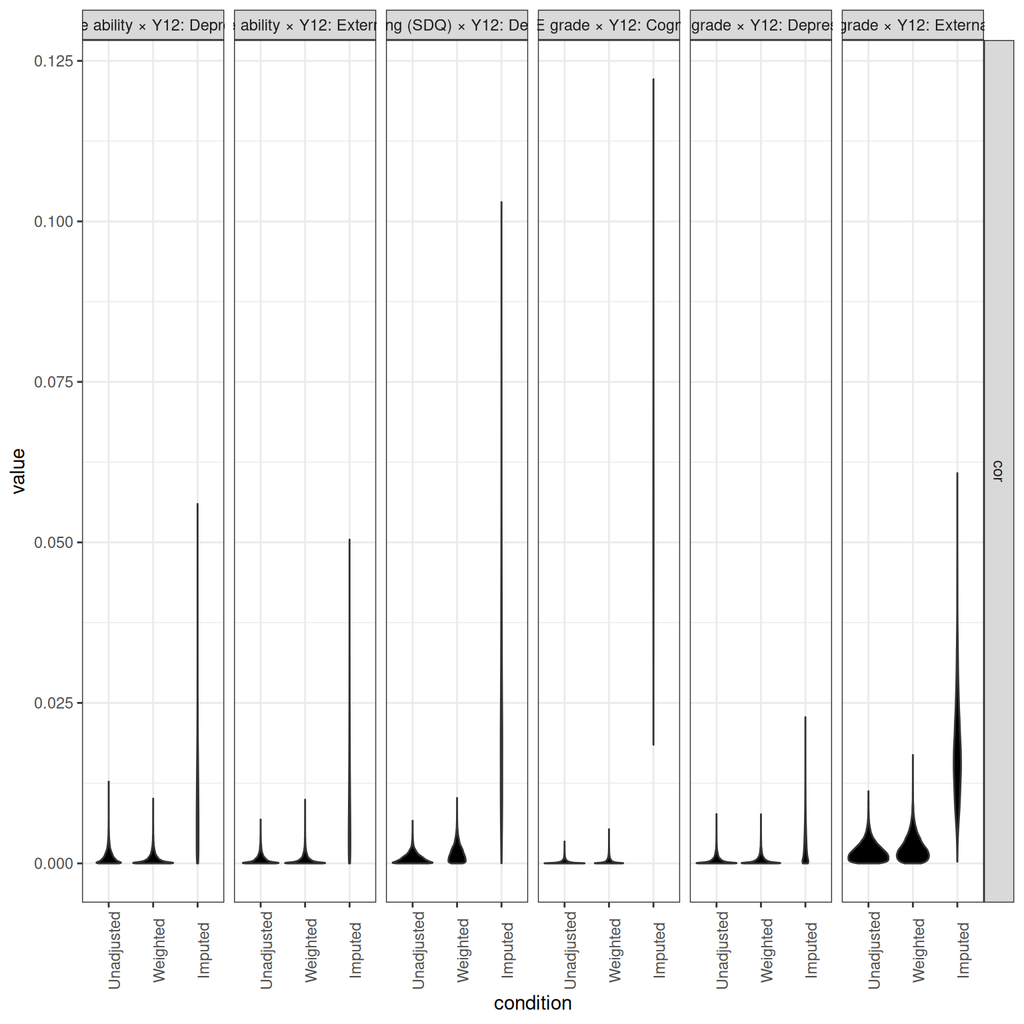

```r
combined_results_mse = combined_results %>%
  mutate(
    condition = factor(condition, levels = c("Unadjusted","Weighted", "Imputed")),
    param = str_extract(stat, "^[^_]+"),
    variable_raw = str_remove(stat, "^[^_]+_"),
    var1 = case_when(
      param == "cor" ~ str_extract(variable_raw, "^[^_]+"),
      TRUE ~ variable_raw
    ),
    var2 = case_when(
      param == "cor" ~ str_extract(variable_raw, "[^_]+$"),
      TRUE ~ NA_character_
    ),
    var1_label = rq6y_labels[match(var1, rq6y)],
    var2_label = rq6y_labels[match(var2, rq6y)],
    variable_pair = paste0(var1_label, " × ", var2_label),
    variable = rq6y_labels[match(variable_raw, rq6y)],
    variable = ifelse(is.na(variable), variable_pair, variable),
    value = value^2
  )

combined_results_mse %>%
  filter(timepoint == "Y26 (web test)") %>%
  filter(param == "cor") %>%
  select(-stat) %>%
  ggplot(aes(y = value, x = condition)) +
  geom_violin(fill = "black") +
  facet_grid(param ~ variable, scales = "free_y") +
  theme_bw() +
  theme(
    axis.text.x = element_text(angle = 90)
  )
```

#### Consistently Most Accurate Method (Heatmap)

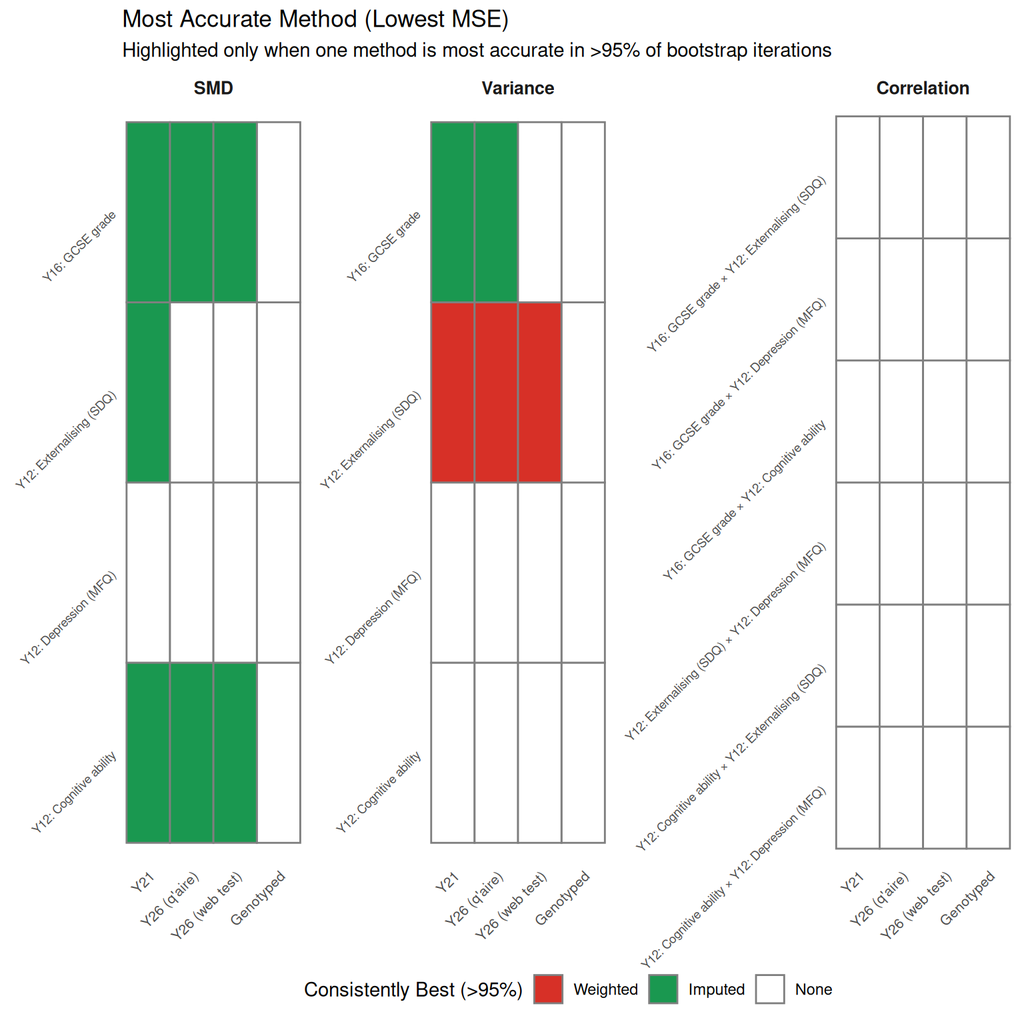

```r
# For each iteration, determine which method has lowest squared error
# Then calculate proportion of times each method wins
mse_consistency = combined_results_mse %>%
  select(variable, param, timepoint, condition, iteration, value) %>%
  pivot_wider(
    names_from = condition,
    values_from = value
  ) %>%
  mutate(
    best = case_when(
      Imputed <= Weighted & Imputed <= Unadjusted ~ "Imputed",
      Weighted <= Imputed & Weighted <= Unadjusted ~ "Weighted",
      TRUE ~ "Unadjusted"
    )
  ) %>%
  group_by(variable, param, timepoint) %>%
  summarise(
    p_unadjusted = mean(best == "Unadjusted"),
    p_weighted = mean(best == "Weighted"),
    p_imputed = mean(best == "Imputed"),
    .groups = "drop"
  ) %>%
  mutate(
    # Only highlight if one method wins >95% of the time
    best_method = case_when(
      p_imputed > 0.95 ~ "Imputed",
      p_weighted > 0.95 ~ "Weighted",
      p_unadjusted > 0.95 ~ "Unadjusted",
      TRUE ~ "None"
    ),
    best_method = factor(best_method, levels = c("Unadjusted", "Weighted", "Imputed", "None"))
  )

# Create heatmap showing consistently winning method
mse_consistency %>%
  mutate(
    param = case_when(
      param == "smd" ~ "SMD",
      param == "var" ~ "Variance",
      param == "cor" ~ "Correlation"
    ),
    param = factor(param, levels = c("SMD", "Variance", "Correlation")),
    timepoint = factor(timepoint, levels = c("Y21", "Y26 (q'aire)", "Y26 (web test)", "Genotyped"))
  ) %>%
  ggplot(aes(x = timepoint, y = variable, fill = best_method)) +
  geom_tile(color = "grey50", linewidth = 0.5) +
  facet_wrap(~param, scales = "free_y", ncol = 3) +
  scale_fill_manual(
    values = c("Unadjusted" = "#fee08b", "Weighted" = "#d73027", "Imputed" = "#1a9850", "None" = "white"),
    name = "Consistently Best (>95%)"
  ) +
  labs(
    title = "Most Accurate Method (Lowest MSE)",
    subtitle = "Highlighted only when one method is most accurate in >95% of bootstrap iterations",
    x = NULL,
    y = NULL
  ) +
  theme_minimal() +
  theme(
    axis.text.x = element_text(angle = 45, hjust = 1, size = 8),
    axis.text.y = element_text(angle = 45, hjust = 1, size = 7),
    strip.text = element_text(face = "bold", size = 10),
    panel.grid = element_blank(),
    legend.position = "bottom"
  )
```

```r
save_plot("9_lowest_mse_method", width = 8, height = 8)
```

📊 View Plot (PNG)

#### Proportion of Iterations Each Method is Most Accurate (Stacked Bar)

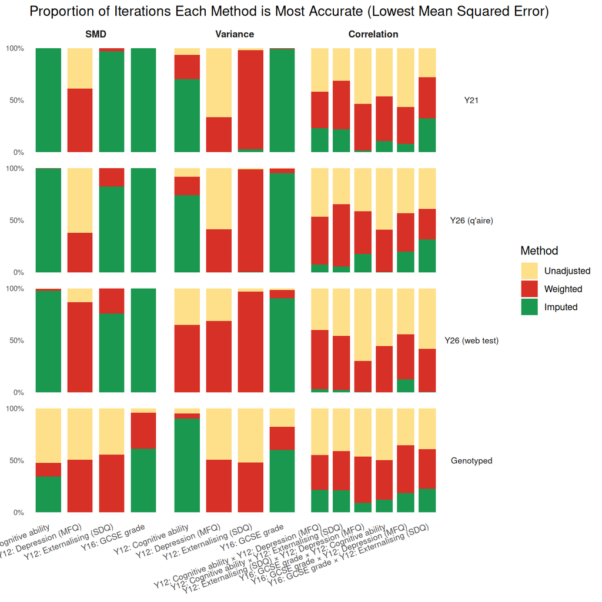

```r
# Stacked bar chart showing proportion of times each method wins
mse_consistency_long = mse_consistency %>%
  select(variable, param, timepoint, p_unadjusted, p_weighted, p_imputed) %>%
  pivot_longer(
    cols = starts_with("p_"),
    names_to = "method",
    values_to = "proportion",
    names_prefix = "p_"
  ) %>%
  mutate(
    method = str_to_title(method),
    method = factor(method, levels = c("Unadjusted", "Weighted", "Imputed")),
    param = case_when(
      param == "smd" ~ "SMD",
      param == "var" ~ "Variance",
      param == "cor" ~ "Correlation"
    ),
    param = factor(param, levels = c("SMD", "Variance", "Correlation")),
    timepoint = factor(timepoint, levels = c("Y21", "Y26 (q'aire)", "Y26 (web test)", "Genotyped"))
  )

mse_consistency_long %>%
  ggplot(aes(x = variable, y = proportion, fill = method)) +
  geom_col(position = "stack", width = 0.8) +
  facet_grid(timepoint ~ param, scales = "free_x") +
  scale_fill_manual(
    values = c("Unadjusted" = "#fee08b", "Weighted" = "#d73027", "Imputed" = "#1a9850"),
    name = "Method"
  ) +
  scale_y_continuous(labels = scales::percent, breaks = c(0, 0.5, 1)) +
  labs(
    title = "Proportion of Iterations Each Method is Most Accurate (Lowest Mean Squared Error)",
    x = NULL,
    y = NULL
  ) +
  theme_minimal() +
  theme(
    axis.text.x = element_text(angle = 20, hjust = 1, size = 8),
    axis.text.y = element_text(size = 7),
    strip.text.x = element_text(face = "bold", size = 9),
    strip.text.y = element_text(angle = 0, size = 8),
    panel.grid = element_blank(),
    legend.position = "right"
  )
```

```r
save_plot("9_lowest_mse_method_stacked", width = 9, height = 6)
```

📊 View Plot (PNG)

# Extra Plots

## Correlation Differences

```r
# Shared wrangling used by both the annotations and the main plot
plot_data_cor = combined_results %>%
  mutate(
    condition    = factor(condition, levels = c("Unadjusted", "Weighted", "Imputed")),
    param        = str_extract(stat, "^[^_]+"),
    variable_raw = str_remove(stat, "^[^_]+_")
  ) %>%
  filter(param == "cor") %>%
  mutate(
    var1       = str_extract(variable_raw, "^[^_]+"),
    var2       = str_extract(variable_raw, "[^_]+$"),
    var1_label = rq6y_labels[match(var1, rq6y)],
    var2_label = rq6y_labels[match(var2, rq6y)],
    pair_label = paste0(var1_label, " ×\n", var2_label),
    timepoint  = factor(timepoint, levels = rq1y_twin_labels_clean_extrashort)
  )

# Point estimate + 95% CI per condition × pair × timepoint (for in-panel annotations)
panel_labels = plot_data_cor %>%
  group_by(condition, pair_label, timepoint) %>%
  summarise(
    est = mean(value),
    lo  = quantile(value, 0.025),
    hi  = quantile(value, 0.975),
    .groups = "drop"
  ) %>%
  mutate(label = sprintf("%+.3f [%+.3f, %+.3f]", est, lo, hi))
```

### Descriptive Stats

```r
plot_data_cor %>%
  group_by(condition) %>%
  summarise(
    .mean_qi_pd(value, .width = .95)
  )
```

| condition | y | ymin | ymax | .width | .point | .interval | pd | pval | n |
| --- | --- | --- | --- | --- | --- | --- | --- | --- | --- |
| Unadjusted | 0.008451327 | -0.01803506 | 0.04901803 | 0.95 | mean | qi | 0.6635500 | 0.6729000 | 240000 |
| Weighted | 0.007530531 | -0.02374573 | 0.05450419 | 0.95 | mean | qi | 0.6343875 | 0.7312250 | 240000 |
| Imputed | 0.001192763 | -0.23367447 | 0.13905821 | 0.95 | mean | qi | 0.5576833 | 0.8846333 | 240000 |

```r
plot_data_cor %>%
  group_by(condition) %>%
  summarise(
    .mean_qi_pd(value, .width = .99)
  )
```

| condition | y | ymin | ymax | .width | .point | .interval | pd | pval | n |
| --- | --- | --- | --- | --- | --- | --- | --- | --- | --- |
| Unadjusted | 0.008451327 | -0.02766358 | 0.06454292 | 0.99 | mean | qi | 0.6635500 | 0.6729000 | 240000 |
| Weighted | 0.007530531 | -0.03576222 | 0.07230543 | 0.99 | mean | qi | 0.6343875 | 0.7312250 | 240000 |
| Imputed | 0.001192763 | -0.27363555 | 0.17305883 | 0.99 | mean | qi | 0.5576833 | 0.8846333 | 240000 |

### Density Plot of Correlation Bias

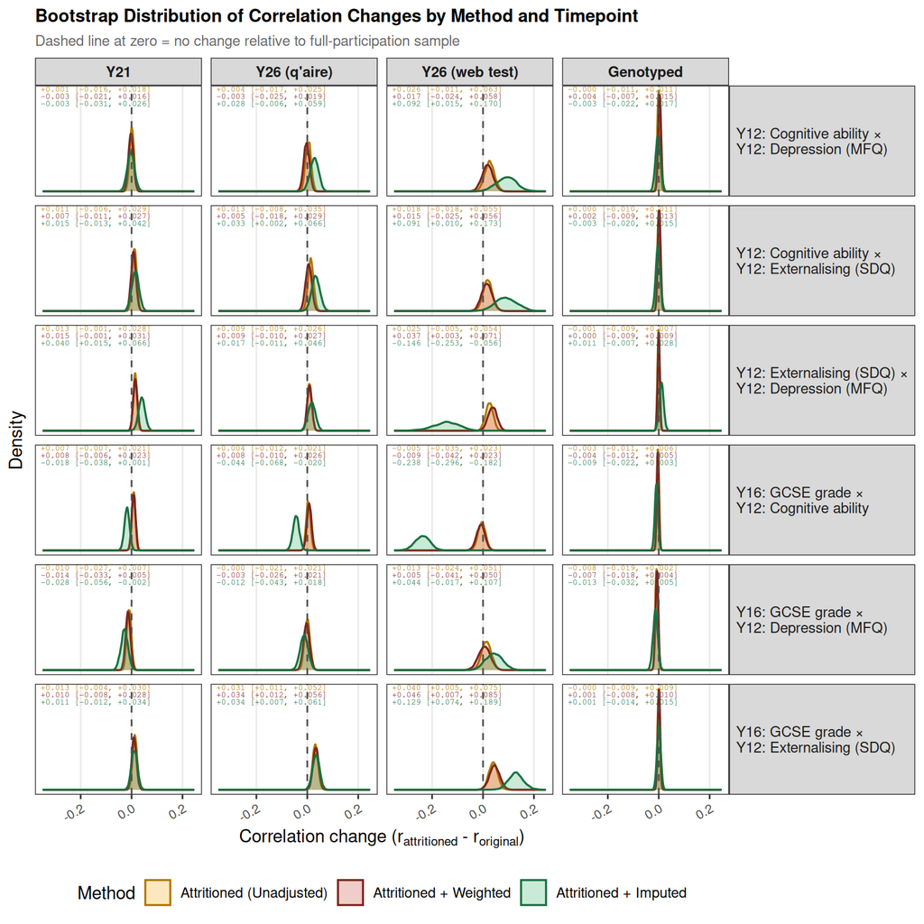

```r
plot_data_cor %>%
  ggplot(aes(x = value, fill = condition, color = condition)) +
  geom_density(alpha = 0.25, linewidth = 0.6) +
  geom_vline(xintercept = 0, linetype = "dashed", color = "grey30", linewidth = 0.5) +
  # Annotations: one geom_text per condition so each gets its own colour and vjust row
  geom_text(
    data = filter(panel_labels, condition == "Unadjusted"),
    aes(x = -Inf, y = Inf, label = label),
    color = "#b07800", hjust = -0.05, vjust = 1.3,
    size = 1.8, family = "mono", inherit.aes = FALSE
  ) +
  geom_text(
    data = filter(panel_labels, condition == "Weighted"),
    aes(x = -Inf, y = Inf, label = label),
    color = "#7b241c", hjust = -0.05, vjust = 2.8,
    size = 1.8, family = "mono", inherit.aes = FALSE
  ) +
  geom_text(
    data = filter(panel_labels, condition == "Imputed"),
    aes(x = -Inf, y = Inf, label = label),
    color = "#1a7040", hjust = -0.05, vjust = 4.3,
    size = 1.8, family = "mono", inherit.aes = FALSE
  ) +
  facet_grid(pair_label ~ timepoint, scales = "free_y") +
  scale_fill_manual(
    values = c("Unadjusted" = "#f0a500", "Weighted" = "#c0392b", "Imputed" = "#27ae60"),
    labels = c("Unadjusted" = "Attritioned (Unadjusted)", "Weighted" = "Attritioned + Weighted", "Imputed" = "Attritioned + Imputed"),
    name = "Method"
  ) +
  scale_color_manual(
    values = c("Unadjusted" = "#b07800", "Weighted" = "#7b241c", "Imputed" = "#1a7040"),
    labels = c("Unadjusted" = "Attritioned (Unadjusted)", "Weighted" = "Attritioned + Weighted", "Imputed" = "Attritioned + Imputed"),
    name = "Method"
  ) +
  labs(
    title    = "Bootstrap Distribution of Correlation Changes by Method and Timepoint",
    subtitle = "Dashed line at zero = no change relative to full-participation sample",
    x        = expression("Correlation change (" * r[attritioned] * " - " * r[original] * ")"),
    y        = "Density"
  ) +
  theme_bw() +
  theme(
    axis.text.x        = element_text(angle = 30, hjust = 1, size = 8),
    axis.text.y        = element_blank(),
    axis.ticks.y       = element_blank(),
    strip.text.x       = element_text(face = "bold", size = 9),
    strip.text.y       = element_text(size = 9, angle = 0, hjust = 0),
    panel.grid.minor   = element_blank(),
    panel.grid.major.y = element_blank(),
    legend.position    = "bottom",
    plot.title         = element_text(size = 11, face = "bold"),
    plot.subtitle      = element_text(size = 9, color = "grey40")
  )
```

```r
save_plot("9_extra_correlation_densities", width = 8, height = 9)
```

📊 View Plot (PNG)

### Density Plot of Absolute Correlation Bias

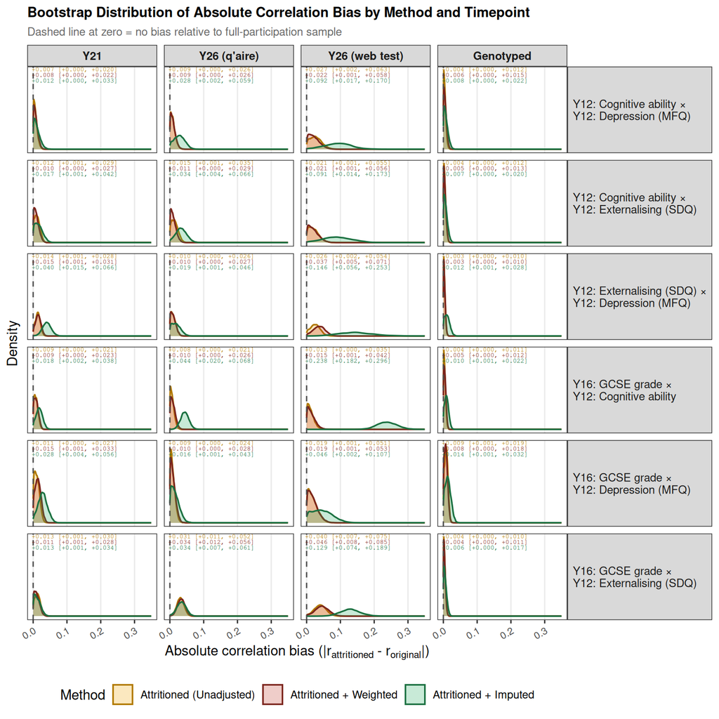

```r
panel_labels_abs = plot_data_cor %>%
  group_by(condition, pair_label, timepoint) %>%
  summarise(
    est = mean(abs(value)),
    lo  = quantile(abs(value), 0.025),
    hi  = quantile(abs(value), 0.975),
    .groups = "drop"
  ) %>%
  mutate(label = sprintf("%+.3f [%+.3f, %+.3f]", est, lo, hi))

plot_data_cor %>%
  ggplot(aes(x = abs(value), fill = condition, color = condition)) +
  geom_density(alpha = 0.25, linewidth = 0.6) +
  geom_vline(xintercept = 0, linetype = "dashed", color = "grey30", linewidth = 0.5) +
  geom_text(
    data = filter(panel_labels_abs, condition == "Unadjusted"),
    aes(x = -Inf, y = Inf, label = label),
    color = "#b07800", hjust = -0.05, vjust = 1.3,
    size = 1.8, family = "mono", inherit.aes = FALSE
  ) +
  geom_text(
    data = filter(panel_labels_abs, condition == "Weighted"),
    aes(x = -Inf, y = Inf, label = label),
    color = "#7b241c", hjust = -0.05, vjust = 2.8,
    size = 1.8, family = "mono", inherit.aes = FALSE
  ) +
  geom_text(
    data = filter(panel_labels_abs, condition == "Imputed"),
    aes(x = -Inf, y = Inf, label = label),
    color = "#1a7040", hjust = -0.05, vjust = 4.3,
    size = 1.8, family = "mono", inherit.aes = FALSE
  ) +
  facet_grid(pair_label ~ timepoint, scales = "free_y") +
  scale_fill_manual(
    values = c("Unadjusted" = "#f0a500", "Weighted" = "#c0392b", "Imputed" = "#27ae60"),
    labels = c("Unadjusted" = "Attritioned (Unadjusted)", "Weighted" = "Attritioned + Weighted", "Imputed" = "Attritioned + Imputed"),
    name = "Method"
  ) +
  scale_color_manual(
    values = c("Unadjusted" = "#b07800", "Weighted" = "#7b241c", "Imputed" = "#1a7040"),
    labels = c("Unadjusted" = "Attritioned (Unadjusted)", "Weighted" = "Attritioned + Weighted", "Imputed" = "Attritioned + Imputed"),
    name = "Method"
  ) +
  labs(
    title    = "Bootstrap Distribution of Absolute Correlation Bias by Method and Timepoint",
    subtitle = "Dashed line at zero = no bias relative to full-participation sample",
    x        = expression("Absolute correlation bias (|" * r[attritioned] * " - " * r[original] * "|)"),
    y        = "Density"
  ) +
  theme_bw() +
  theme(
    axis.text.x        = element_text(angle = 30, hjust = 1, size = 8),
    axis.text.y        = element_blank(),
    axis.ticks.y       = element_blank(),
    strip.text.x       = element_text(face = "bold", size = 9),
    strip.text.y       = element_text(size = 9, angle = 0, hjust = 0),
    panel.grid.minor   = element_blank(),
    panel.grid.major.y = element_blank(),
    legend.position    = "bottom",
    plot.title         = element_text(size = 11, face = "bold"),
    plot.subtitle      = element_text(size = 9, color = "grey40")
  )
```

```r
save_plot("9_extra_correlation_densities_abs", width = 8, height = 9)
```

📊 View Plot (PNG)

# ACE Summary Estimates

## Extract ACE Differences from All Conditions

### Unadjusted

```r
# Unadjusted: use pre-computed bootstrap summaries already stored in res_unadj
# differences between full-sample and attritioned (unadjusted) ACE estimates
ace_diff_unadj = lapply(seq_along(rq1y_twin1), function(i) {
  res_unadj[[rq1y_twin1[i]]]$ace_diff_summary %>%
    mutate(
      timepoint  = rq1y_twin_labels_clean_extrashort[i],
      condition  = "Unadjusted",
      name_clean = rq6y_labels[match(name, rq6y)]
    )
}) %>%
  bind_rows()

ace_diff_unadj
```

| par | name | sex | y | ymin | ymax | .width | .point | .interval | pd | pval | n | timepoint | condition | name_clean |
| --- | --- | --- | --- | --- | --- | --- | --- | --- | --- | --- | --- | --- | --- | --- |
| a | lcg1 | female | 0.0390657715 | -4.112431e-02 | 0.1196713842 | 0.95 | mean | qi | 0.8304 | 0.3392 | 10000 | Y21 | Unadjusted | Y12: Cognitive ability |
| a | lcg1 | male | 0.1027767227 | -3.695851e-02 | 0.2405306629 | 0.95 | mean | qi | 0.9259 | 0.1482 | 10000 | Y21 | Unadjusted | Y12: Cognitive ability |
| a | lcmfqt1 | female | -0.0724547721 | -2.081738e-01 | 0.0602736873 | 0.95 | mean | qi | 0.8528 | 0.2944 | 10000 | Y21 | Unadjusted | Y12: Depression (MFQ) |
| a | lcmfqt1 | male | -0.0263934294 | -2.658451e-01 | 0.1210234561 | 0.95 | mean | qi | 0.5073 | 0.9854 | 10000 | Y21 | Unadjusted | Y12: Depression (MFQ) |
| a | lsdqext1 | female | 0.0140109397 | -4.709139e-02 | 0.0786573961 | 0.95 | mean | qi | 0.7367 | 0.5266 | 10000 | Y21 | Unadjusted | Y12: Externalising (SDQ) |
| a | lsdqext1 | male | -0.0849791058 | -2.523244e-01 | 0.0235156513 | 0.95 | mean | qi | 0.9251 | 0.1498 | 10000 | Y21 | Unadjusted | Y12: Externalising (SDQ) |
| a | pcexgcsecoregrdm1 | female | 0.0471776686 | -1.360033e-02 | 0.1085790412 | 0.95 | mean | qi | 0.9347 | 0.1306 | 10000 | Y21 | Unadjusted | Y16: GCSE grade |
| a | pcexgcsecoregrdm1 | male | -0.0413037153 | -1.704269e-01 | 0.0875481918 | 0.95 | mean | qi | 0.7404 | 0.5192 | 10000 | Y21 | Unadjusted | Y16: GCSE grade |
| c | lcg1 | female | -0.0515802587 | -1.277926e-01 | 0.0231222317 | 0.95 | mean | qi | 0.9107 | 0.1786 | 10000 | Y21 | Unadjusted | Y12: Cognitive ability |
| c | lcg1 | male | -0.0740106068 | -2.009547e-01 | 0.0526594637 | 0.95 | mean | qi | 0.8746 | 0.2508 | 10000 | Y21 | Unadjusted | Y12: Cognitive ability |

[output cut: 86 more lines]

### Weighted

```r
# Weighted: summarise raw bootstrap iterations
ace_diff_weigh_list = vector("list", length(rq1y_twin1))

for (i in seq_along(rq1y_twin1)) {
  ace_results = lapply(res_weigh[[i]], function(x) x$ace)
  ace_results = lapply(ace_results, function(x) {
    x[[2]]$group = "difference"
    x[[4]]$group = "difference"
    return(x)
  })
  ace_results = lapply(ace_results, function(x) do.call(rbind, x))
  ace_results = do.call(rbind, ace_results) %>%
    filter(par %in% c("a", "c", "e"))

  ace_diff_weigh_list[[i]] = ace_results %>%
    filter(group == "difference") %>%
    group_by(par, name, sex) %>%
    summarise(.mean_qi_pd(value), .groups = "drop") %>%
    mutate(
      timepoint  = rq1y_twin_labels_clean_extrashort[i],
      condition  = "Weighted",
      name_clean = rq6y_labels[match(name, rq6y)]
    )
}
ace_diff_weigh = bind_rows(ace_diff_weigh_list)
ace_diff_weigh
```

| par | name | sex | y | ymin | ymax | .width | .point | .interval | pd | pval | n | timepoint | condition | name_clean |
| --- | --- | --- | --- | --- | --- | --- | --- | --- | --- | --- | --- | --- | --- | --- |
| a | lcg1 | female | 4.141932e-02 | -4.133392e-02 | 0.123890461 | 0.95 | mean | qi | 0.8400 | 0.3200 | 10000 | Y21 | Weighted | Y12: Cognitive ability |
| a | lcg1 | male | 1.412621e-01 | -6.910261e-03 | 0.290873772 | 0.95 | mean | qi | 0.9684 | 0.0632 | 10000 | Y21 | Weighted | Y12: Cognitive ability |
| a | lcmfqt1 | female | -1.027432e-01 | -2.361928e-01 | 0.025676332 | 0.95 | mean | qi | 0.9350 | 0.1300 | 10000 | Y21 | Weighted | Y12: Depression (MFQ) |
| a | lcmfqt1 | male | -1.575999e-02 | -2.594952e-01 | 0.128262770 | 0.95 | mean | qi | 0.5264 | 0.9472 | 10000 | Y21 | Weighted | Y12: Depression (MFQ) |
| a | lsdqext1 | female | 1.758280e-02 | -5.036079e-02 | 0.080399544 | 0.95 | mean | qi | 0.7865 | 0.4270 | 10000 | Y21 | Weighted | Y12: Externalising (SDQ) |
| a | lsdqext1 | male | -4.760688e-02 | -2.044574e-01 | 0.059462048 | 0.95 | mean | qi | 0.7854 | 0.4292 | 10000 | Y21 | Weighted | Y12: Externalising (SDQ) |
| a | pcexgcsecoregrdm1 | female | 4.996099e-02 | -1.514001e-02 | 0.115975750 | 0.95 | mean | qi | 0.9333 | 0.1334 | 10000 | Y21 | Weighted | Y16: GCSE grade |
| a | pcexgcsecoregrdm1 | male | -4.498660e-02 | -1.806552e-01 | 0.089897264 | 0.95 | mean | qi | 0.7472 | 0.5056 | 10000 | Y21 | Weighted | Y16: GCSE grade |
| c | lcg1 | female | -5.292256e-02 | -1.307464e-01 | 0.023602042 | 0.95 | mean | qi | 0.9134 | 0.1732 | 10000 | Y21 | Weighted | Y12: Cognitive ability |
| c | lcg1 | male | -1.201123e-01 | -2.562154e-01 | 0.015082343 | 0.95 | mean | qi | 0.9583 | 0.0834 | 10000 | Y21 | Weighted | Y12: Cognitive ability |

[output cut: 86 more lines]

### Imputed

```r
# Imputed: summarise across bootstrap iterations × imputed datasets
n_imputed_ace = 250

ace_diff_imput_list = vector("list", length(rq1y_twin1))

for (tp in seq_along(rq1y_twin1)) {
  timepoint_prefix = gsub("1$", "", rq1y_twin1[tp])

  all_ace = vector("list", n_imputed_ace)
  for (m in seq_len(n_imputed_ace)) {
    dataset_name = paste0(timepoint_prefix, m)
    imp_data     = res_imput[[dataset_name]]
    # imp_data$ace: list of bootstrap iterations, each a list of dataframes
    ace_iter     = lapply(imp_data$ace, function(x) do.call(rbind, x))
    all_ace[[m]] = do.call(rbind, ace_iter)
  }

  ace_diff_imput_list[[tp]] = bind_rows(all_ace) %>%
    filter(par %in% c("a", "c", "e"), group == "diff") %>%
    group_by(par, name, sex) %>%
    summarise(.mean_qi_pd(value), .groups = "drop") %>%
    mutate(
      timepoint  = rq1y_twin_labels_clean_extrashort[tp],
      condition  = "Imputed",
      name_clean = rq6y_labels[match(name, rq6y_prefix)]
    )
}
ace_diff_imput = bind_rows(ace_diff_imput_list)
ace_diff_imput
```

| par | name | sex | y | ymin | ymax | .width | .point | .interval | pd | pval | n | timepoint | condition | name_clean |
| --- | --- | --- | --- | --- | --- | --- | --- | --- | --- | --- | --- | --- | --- | --- |
| a | lcg | female | 0.0493460865 | -0.0713740866 | 0.1705101496 | 0.95 | mean | qi | 0.7911 | 0.4178 | 10000 | Y21 | Imputed | Y12: Cognitive ability |
| a | lcg | male | 0.1134364842 | -0.1292384422 | 0.3434869708 | 0.95 | mean | qi | 0.8245 | 0.3510 | 10000 | Y21 | Imputed | Y12: Cognitive ability |
| a | lcmfqt | female | -0.0151293825 | -0.2233247471 | 0.1932338840 | 0.95 | mean | qi | 0.5538 | 0.8924 | 10000 | Y21 | Imputed | Y12: Depression (MFQ) |
| a | lcmfqt | male | 0.0430157644 | -0.1702753709 | 0.1997867551 | 0.95 | mean | qi | 0.7436 | 0.5128 | 10000 | Y21 | Imputed | Y12: Depression (MFQ) |
| a | lsdqext | female | 0.0446652866 | -0.0370424449 | 0.1354428436 | 0.95 | mean | qi | 0.8978 | 0.2044 | 10000 | Y21 | Imputed | Y12: Externalising (SDQ) |
| a | lsdqext | male | -0.1159841847 | -0.3300112344 | 0.0385257766 | 0.95 | mean | qi | 0.9303 | 0.1394 | 10000 | Y21 | Imputed | Y12: Externalising (SDQ) |
| a | pcexgcsecoregrdm | female | 0.0419457159 | -0.0256215039 | 0.1150373009 | 0.95 | mean | qi | 0.8779 | 0.2442 | 10000 | Y21 | Imputed | Y16: GCSE grade |
| a | pcexgcsecoregrdm | male | -0.0024181086 | -0.1459233841 | 0.1509194931 | 0.95 | mean | qi | 0.5211 | 0.9578 | 10000 | Y21 | Imputed | Y16: GCSE grade |
| c | lcg | female | -0.0706543387 | -0.1829652467 | 0.0367347734 | 0.95 | mean | qi | 0.9041 | 0.1918 | 10000 | Y21 | Imputed | Y12: Cognitive ability |
| c | lcg | male | -0.1860203177 | -0.3812990560 | 0.0131676529 | 0.95 | mean | qi | 0.9667 | 0.0666 | 10000 | Y21 | Imputed | Y12: Cognitive ability |

[output cut: 86 more lines]

## RQ3: Comparison of Unadjusted/Weighted/Imputed Attritioned Estimates to Original Estimates

The table below compares the ACE (Additive genetic, shared environment, non-shared environment) variance component estimates from the Unadjusted, IP-Weighted, and Imputed attritioned samples to the original full-sample estimates, separately by sex, outcome, and attrition timepoint. It reports the difference (attritioned condition − original) with 95% CIs and Bonferroni-Holm adjusted p-values (adjusted within each condition × timepoint × sex group); significant increases are shaded orange and decreases blue.

```r
ace_diff_combined = bind_rows(ace_diff_unadj, ace_diff_weigh, ace_diff_imput) %>%
  mutate(
    condition = factor(condition, levels = c("Unadjusted", "Weighted", "Imputed")),
    timepoint = factor(timepoint, levels = rq1y_twin_labels_clean_extrashort),
    par       = toupper(par),
    sex       = str_to_title(sex)
  ) %>%
  group_by(condition, timepoint, sex) %>%
  mutate(pval_adj = stats::p.adjust(pval, method = "holm")) %>%
  ungroup()

ace_diff_combined %>%
  select(sex, condition, timepoint, par, name_clean, y, ymin, ymax, pval, pval_adj) %>%
  arrange(sex, name_clean, par, condition, timepoint) %>%
  gt(groupname_col = "sex") %>%
  cols_label(
    condition  = "Condition",
    timepoint  = "Timepoint",
    par        = "Par",
    name_clean = "Variable",
    y          = "Est",
    ymin       = "Lower",
    ymax       = "Upper",
    pval       = md("p"),
    pval_adj   = md("p<sub>adj</sub>")
  ) %>%
  fmt_number(columns = c(y, ymin, ymax), decimals = 3) %>%
  fmt_number(columns = c(pval, pval_adj), decimals = 4) %>%
  tab_style(
    style = cell_text(size = px(10)),
    locations = list(
      cells_body(), cells_stub(), cells_row_groups(), cells_column_labels()
    )
  ) %>%
  tab_style(
    style = cell_fill(color = "#ffd9d1"),
    locations = cells_body(
      columns = c(y, ymin, ymax, pval, pval_adj),
      rows = pval_adj < 0.05 & y > 0
    )
  ) %>%
  tab_style(
    style = cell_fill(color = "#b6c3e0"),
    locations = cells_body(
      columns = c(y, ymin, ymax, pval, pval_adj),
      rows = pval_adj < 0.05 & y < 0
    )
  ) %>%
  tab_footnote(
    footnote = md("<em>Note.</em> Difference = Attritioned − Original. Par: A = additive genetic, C = shared environment, E = unique environment. Significant (p<sub>adj</sub> < 0.05) effects highlighted in orange (increases) or blue (decreases). P values Bonferroni-Holm adjusted within each condition × timepoint × sex group."),
    placement = "right"
  )
```

| Condition | Timepoint | Par | Variable | Est | Lower | Upper | p | p<sub>adj</sub> |
| --- | --- | --- | --- | --- | --- | --- | --- | --- |
| Female |  |  |  |  |  |  |  |  |
| Unadjusted | Y21 | A | Y12: Cognitive ability | 0.039 | −0.041 | 0.120 | 0.3392 | 1.0000 |
| Unadjusted | Y26 (q'aire) | A | Y12: Cognitive ability | 0.028 | −0.077 | 0.132 | 0.6000 | 1.0000 |
| Unadjusted | Y26 (web test) | A | Y12: Cognitive ability | −0.003 | −0.199 | 0.196 | 0.9632 | 1.0000 |
| Unadjusted | Genotyped | A | Y12: Cognitive ability | 0.026 | −0.038 | 0.090 | 0.4390 | 1.0000 |
| Weighted | Y21 | A | Y12: Cognitive ability | 0.041 | −0.041 | 0.124 | 0.3200 | 1.0000 |
| Weighted | Y26 (q'aire) | A | Y12: Cognitive ability | 0.031 | −0.077 | 0.138 | 0.5574 | 1.0000 |
| Weighted | Y26 (web test) | A | Y12: Cognitive ability | −0.007 | −0.200 | 0.192 | 0.9338 | 1.0000 |
| Weighted | Genotyped | A | Y12: Cognitive ability | 0.037 | −0.029 | 0.103 | 0.2624 | 1.0000 |
| Imputed | Y21 | A | Y12: Cognitive ability | 0.049 | −0.071 | 0.171 | 0.4178 | 1.0000 |
| Imputed | Y26 (q'aire) | A | Y12: Cognitive ability | 0.020 | −0.123 | 0.167 | 0.7820 | 1.0000 |
| Imputed | Y26 (web test) | A | Y12: Cognitive ability | −0.043 | −0.322 | 0.202 | 0.8088 | 1.0000 |
| Imputed | Genotyped | A | Y12: Cognitive ability | 0.090 | −0.015 | 0.199 | 0.0974 | 1.0000 |
| Unadjusted | Y21 | C | Y12: Cognitive ability | −0.052 | −0.128 | 0.023 | 0.1786 | 1.0000 |
| Unadjusted | Y26 (q'aire) | C | Y12: Cognitive ability | −0.043 | −0.141 | 0.055 | 0.3872 | 1.0000 |
| Unadjusted | Y26 (web test) | C | Y12: Cognitive ability | −0.016 | −0.203 | 0.168 | 0.8852 | 1.0000 |
| Unadjusted | Genotyped | C | Y12: Cognitive ability | −0.033 | −0.098 | 0.030 | 0.3148 | 1.0000 |
| Weighted | Y21 | C | Y12: Cognitive ability | −0.053 | −0.131 | 0.024 | 0.1732 | 1.0000 |
| Weighted | Y26 (q'aire) | C | Y12: Cognitive ability | −0.044 | −0.143 | 0.054 | 0.3694 | 1.0000 |
| Weighted | Y26 (web test) | C | Y12: Cognitive ability | 0.002 | −0.185 | 0.181 | 0.9750 | 1.0000 |
| Weighted | Genotyped | C | Y12: Cognitive ability | −0.042 | −0.107 | 0.024 | 0.2088 | 1.0000 |
| Imputed | Y21 | C | Y12: Cognitive ability | −0.071 | −0.183 | 0.037 | 0.1918 | 1.0000 |
| Imputed | Y26 (q'aire) | C | Y12: Cognitive ability | −0.071 | −0.203 | 0.051 | 0.2636 | 1.0000 |
| Imputed | Y26 (web test) | C | Y12: Cognitive ability | −0.123 | −0.326 | 0.108 | 0.3144 | 1.0000 |
| Imputed | Genotyped | C | Y12: Cognitive ability | −0.097 | −0.202 | 0.004 | 0.0648 | 0.7776 |
| Unadjusted | Y21 | E | Y12: Cognitive ability | 0.013 | −0.007 | 0.032 | 0.1996 | 1.0000 |
| Unadjusted | Y26 (q'aire) | E | Y12: Cognitive ability | 0.016 | −0.010 | 0.042 | 0.2394 | 1.0000 |
| Unadjusted | Y26 (web test) | E | Y12: Cognitive ability | 0.019 | −0.027 | 0.066 | 0.4204 | 1.0000 |
| Unadjusted | Genotyped | E | Y12: Cognitive ability | 0.008 | −0.001 | 0.016 | 0.0700 | 0.8400 |
| Weighted | Y21 | E | Y12: Cognitive ability | 0.012 | −0.008 | 0.032 | 0.2590 | 1.0000 |

[output cut: 260 more lines]

*Note.* Difference = Attritioned − Original. Par: A = additive genetic, C = shared environment, E = unique environment. Significant (p<sub>adj</sub> < 0.05) effects highlighted in orange (increases) or blue (decreases). P values Bonferroni-Holm adjusted within each condition × timepoint × sex group.

## ACE Bias Plot

The plot below visualises the same ACE differences as the table above (bias = attritioned − original estimate, with 95% CI), faceted by outcome/sex (rows) and ACE parameter/timepoint (columns), and coloured by bias-correction condition (Unadjusted, Weighted, Imputed). Faded points are not statistically significant; a dashed line marks zero bias.

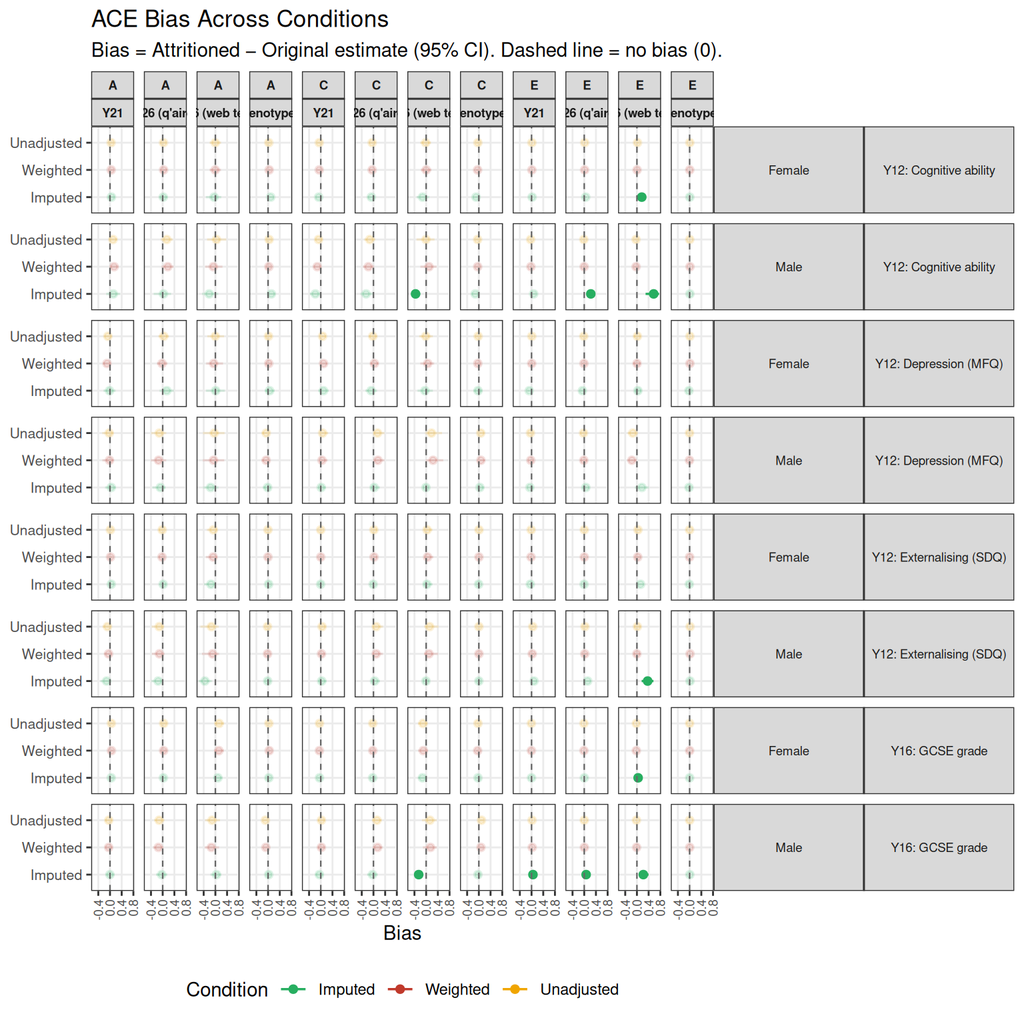

```r
ace_diff_combined %>%
  mutate(condition = fct_rev(condition)) %>%
  ggplot(aes(
    x     = y,
    xmin  = ymin,
    xmax  = ymax,
    y     = condition,
    color = condition,
    alpha = pval_adj < 0.05
  )) +
  geom_pointrange(size = 0.3, linewidth = 0.6) +
  geom_vline(xintercept = 0, linetype = "dashed", color = "grey40", linewidth = 0.4) +
  facet_grid(name_clean + sex ~ par + timepoint, scales = "fixed") +
  scale_color_manual(
    values = c("Unadjusted" = "#f0a500", "Weighted" = "#c0392b", "Imputed" = "#27ae60")
  ) +
  scale_alpha_manual(values = c("TRUE" = 1, "FALSE" = 0.15), guide = "none") +
  labs(
    title    = "ACE Bias Across Conditions",
    subtitle = "Bias = Attritioned − Original estimate (95% CI). Dashed line = no bias (0).",
    x        = "Bias",
    y        = NULL,
    color    = "Condition"
  ) +
  theme_bw() +
  theme(
    strip.text.x     = element_text(size = 7, face = "bold"),
    strip.text.y     = element_text(size = 7, angle = 0),
    axis.text.y      = element_text(size = 8),
    axis.text.x      = element_text(size = 7, angle = 90, vjust = 0.5, hjust = 1),
    panel.grid.minor = element_blank(),
    legend.position  = "bottom"
  )
```

```r
save_plot("9_ace_bias_conditions", width = 13, height = 4.8)
```

📊 View Plot (PNG)

# Calculate Bias Reduction - ACE